# Progetto SAD

Popolazione 25 anni e oltre per titolo di studio

Esposito Flavio

# Introduzione

Lo scopo dell’indagine statistica presentata in questo documento è quello di analizzare i dati forniti dall’ISTAT sulla popolazione italiana rispetto ai **titoli di studio**.  
L’obiettivo è ottenere informazioni dalle quali ricavare ulteriore conoscenza e poter fare **considerazioni sul fenomeno analizzato**.  
L’argomento merita particolare attenzione: diversi sono gli aspetti della vita, anche i meno scontati, che sono statisticamente legati al livello di istruzione.  
Sempre maggiori infatti sono gli studi che si concentrano sulla **correlazione tra il livello di istruzione dei cittadini e il loro stile di vita**.  
I dati sulla povertà come ad esempio quello presentato dal **[rapporto sulla povertà della caritas](http://www.caritasitaliana.it/caritasitaliana/allegati/7847/Poverta%20in%20Attesa_Sintesi.pdf)** mostrano come la povertà educativa e culturale in Italia influisca pesantemente sul benessere degli individui, specialmente confrontando i dati italiani con quelli del resto dell’Europa.  
Un altro esempio riguarda gli studi dell’Osservatorio Nazionale della Salute nelle Regioni Italiane che evidenziano come il titolo di studio influisca fortemente sulle **condizioni di salute**, sulla speranza di vita e anche sulla rinuncia da parte degli italiani ad almeno una prestazione sanitaria.  
Un’analisi approfondita sul grado di istruzione della popolazione italiana può quindi essere molto interessante per fornire dati in modo da ampliare queste analisi sull’incidenza del livello culturale sullo stile di vita.  
Procediamo quindi mostrando il dataset scelto.

## Dataset

La fonte del **[dataset utilizzato](http://dati.istat.it/Index.aspx?DataSetCode=DCCV_POPTIT1)** è il sito dell’**Istituto nazionale di statistica**.  
Il dataset colleziona dati raccolti su campioni di migliaia di individui per ciascuna regione italiana riguardo il **titolo di studio raggiunto**.  
Il campione considerato è composto da persone comprese nella fascia di età **tra i 25 e i 64 anni**. Per ciascuna regione italiana è indicata, nell’ordine di presentazione, la **percentuale** di individui che hanno ottenuto al più la **licenza elementare**, quelli che hanno terminato gli studi con l’ottenimento della **licenza media**, quelli che hanno conseguito un **diploma professionale**, quelli che hanno ottenuto la **maturità**, e infine sono raggruppati nell’ultima colonna gli individui che hanno come titolo massimo di studio una **laurea o post-laurea**.  
I dati risultano essere relativi all’anno **2017**.

Di seguito dunque la tabella

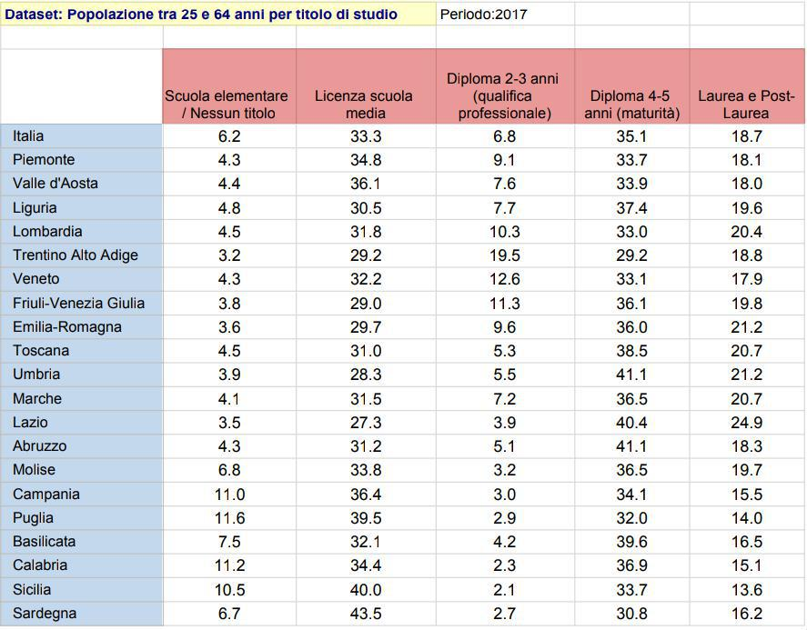

Per la realizzazione del progetto si è scelto di utilizzare il **linguaggio di programmazione e ambiente di sviluppo R** poiché adatto allo specifico obiettivo dell’analisi statistica dei dati.

### Inizializzazione dati matrice

L’azione preliminare necessaria per iniziare la nostra analisi è quella di inizializzare la matrice che utilizzeremo durante la nostra indagine statistica.  
Per ciascuna colonna della tabella creiamo un **vettore**:

```r
licenza_elementare_o_nessuno <- c(4.3, 4.4, 4.8, 4.5, 3.2, 4.3, 3.8,3.6,
                                  4.5,3.9, 4.1, 3.5, 4.3,6.8,11.0, 11.6,
                                  7.5, 11.2, 10.5, 6.7)

licenza_media <- c(34.8, 36.1, 30.5, 31.8, 29.2, 32.2, 29.0, 29.7, 31.0,
                  28.3, 31.5, 27.3, 31.2, 33.8, 36.4, 39.5, 32.1, 34.4,
                  40.0, 43.5)

diploma <- c(9.1, 7.6, 7.7, 10.3, 19.5, 12.6, 11.3, 9.6, 5.3, 5.5, 7.2,
            3.9, 5.1, 3.2, 3.0, 2.9, 4.2, 2.3, 2.1, 2.7)

maturita <- c(33.7, 33.9, 37.4, 33.0, 29.2, 33.1, 36.1, 36.0, 38.5, 41.1,
             36.5, 40.4, 41.1, 36.5, 34.1, 32.0, 39.6, 36.9, 33.7, 30.8)

laurea = c(18.1, 18.0, 19.6, 20.4, 18.8, 17.9, 19.8, 21.2, 20.7, 21.2,
           20.7, 24.9, 18.3, 19.7, 15.5, 14.0, 16.5, 15.1, 13.6, 16.2)
```

A questo punto si può procedere facilmente alla creazione della matrice.  
Utilizziamo i vettori appena definiti per specificare le colonne della matrice. Per la leggibilità della matrice inizializziamo due vettori per definire i nomi associati a colonne e righe:

```r
matricePopolazionePerTitoloDiStudio <- cbind(licenza_elementare_o_nessuno,
                                 licenza_media, diploma, maturita, laurea)

regioni <- c("Piemonte", "Valle d'Aosta", "Liguria", "Lombardia",
"Trentino Alto Adige","Veneto", "Friuli-Venezia Giulia", "Emilia-Romagna",
"Toscana","Umbria", "Marche","Lazio", "Abruzzo", "Molise", "Campania",
"Puglia", "Basilicata", "Calabria", "Sicilia", "Sardegna")
rownames(matricePopolazionePerTitoloDiStudio) <- regioni

titoli <- c("Nessun titolo", "Medie", "Diploma", "Maturità", "Laurea")
colnames(matricePopolazionePerTitoloDiStudio) <- titoli
```

La matrice risultante dalle operazioni precedenti è la seguente:

```
##                       Nessun titolo Medie Diploma Maturità Laurea
## Piemonte                        4.3  34.8     9.1     33.7   18.1
## Valle d'Aosta                   4.4  36.1     7.6     33.9   18.0
## Liguria                         4.8  30.5     7.7     37.4   19.6
## Lombardia                       4.5  31.8    10.3     33.0   20.4
## Trentino Alto Adige             3.2  29.2    19.5     29.2   18.8
## Veneto                          4.3  32.2    12.6     33.1   17.9
## Friuli-Venezia Giulia           3.8  29.0    11.3     36.1   19.8
## Emilia-Romagna                  3.6  29.7     9.6     36.0   21.2
## Toscana                         4.5  31.0     5.3     38.5   20.7
## Umbria                          3.9  28.3     5.5     41.1   21.2
## Marche                          4.1  31.5     7.2     36.5   20.7
## Lazio                           3.5  27.3     3.9     40.4   24.9
## Abruzzo                         4.3  31.2     5.1     41.1   18.3
## Molise                          6.8  33.8     3.2     36.5   19.7
## Campania                       11.0  36.4     3.0     34.1   15.5
## Puglia                         11.6  39.5     2.9     32.0   14.0
## Basilicata                      7.5  32.1     4.2     39.6   16.5
## Calabria                       11.2  34.4     2.3     36.9   15.1
## Sicilia                        10.5  40.0     2.1     33.7   13.6
## Sardegna                        6.7  43.5     2.7     30.8   16.2
```

Infine come ultima operazione preliminare definiamo anche un vettore contenente i nomi delle regioni abbreviate: il vettore sarà utile quando dovremmo visualizzare i grafici e avremo bisogno di indici del genere.

```r
regioniAbbreviate <- c("PIE","VDA","LIG","LOM","TAA","VEN","FVG","ER","TOS",
                     "UMB","MAR","LAZ","ABR","MOL","CAM","PUG","BAS","CAL",
                     "SIC","SAR")
```

# Distribuzioni di frequenza

Il primo passo da fare dopo aver predisposto i dati su cui si lavorerà è di **organizzarli in maniera che siano significativi** anche nella forma in modo da poter facilmente estrapolare le informazioni iniziali non immediatamente evidenti.  
Il primo metodo di cui ci serviamo per organizzare i dati è la **distribuzione di frequenza**. La distribuzione di frequenza è un’organizzazione dei dati in maniera tabulare che permette di rappresentare i valori individuali dei nostri dati in una categoria su una determinata scala. Attraverso la distribuzione di frequenza possiamo avere uno sguardo all’intero set di dati in maniera immediata e semplice. Capiamo se **determinate osservazioni sono più o meno significative** e come sono distribuite sulla scala considerata.  
Prima di costruire una tabella di frequenza si deve conoscere la natura dei dati con i quali si sta avendo a che fare. Considerando la tipologia di dati nel dataset preso in analisi, ad esempio, la scelta migliore è quella di dividere i vari insiemi in **classi**. Nel nostro dataset infatti è immediato notare che tutti i dati a nostra disposizione sono percentuali numeriche e il contenuto di ciascuna colonna della tabella non può assumere valori classificabili all’interno di una ben precisa modalità. La soluzione ideale è quella di **raccogliere le informazioni in classi** e poi calcolare le frequenze con cui gli elementi del campione cadono in ciascuna di esse.  
La scelta dei “range” delle classi deve essere fatta **in modo appropriato** osservando il dataset e tenendo in considerazione che sia utilizzarne pochi che molti è controproducente ai fini dell’analisi. Una buona metrica può essere quella di scegliere i range dividendo i range delle osservazioni col numero di classi scelto.  
La scelta sulle classi è stata fatta dunque nel seguente modo:  
**(0,8] (8,16] (16,24] (24,32] (32,40] (40,48]**  
In r creiamo dunque un vettore per contenere le classi scelte nel seguente modo:

```r
classiScelte <- c(0,8,16,24,32,40,48)
```

L’ambiente R per lavorare con intervalli fornisce la funzione **cut()** che prende in input un vettore e gli estremi degli intervalli considerati (aperti a sinistra).  
Per calcolare la frequenza sull’output di cut utilizziamo invece la funzione table().  
Vediamo dunque prima di tutto la distribuzione di **frequenza assoluta** e successivamente la distribuzione di **frequenza relativa**.

## Distribuzione di frequenza assoluta

Utilizziamo anche dei **grafici a barre** per graficare i risultati.

### Persone con nessun titolo o licenza elementare

```r
table(cut(licenza_elementare_o_nessuno,classiScelte))
```

```
##
##   (0,8]  (8,16] (16,24] (24,32] (32,40] (40,48]
##      16       4       0       0       0       0
```

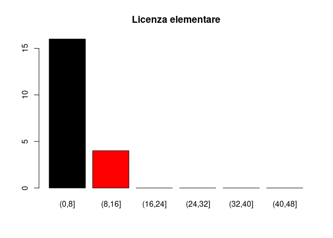

### Persone con licenza media

```r
table(cut(licenza_media,classiScelte))
```

```
##
##   (0,8]  (8,16] (16,24] (24,32] (32,40] (40,48]
##       0       0       0      10       9       1
```

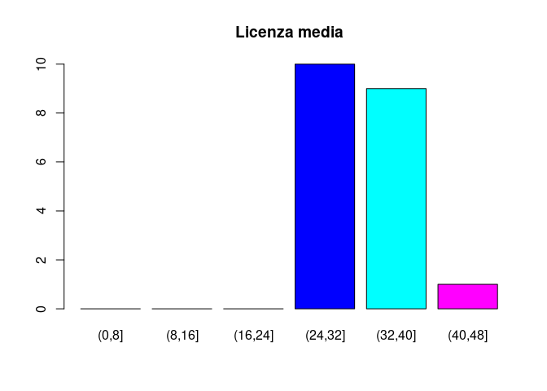

Da questo risultato capiamo che:

- Nel quadro italiano si hanno valori abbastanza diversificati in tutte le regioni riguardo la percentuale di persone che hanno terminato gli studi con la licenza media. La media nazionale si attesta attorno al **33.3%**.
- Risultano essere 10 le regioni che fanno parte della quarta classe e hanno una percentuale leggermente minore rispetto alla media italiana, su tutte abbiamo diverse regioni del centro-nord quali: **Trentino Alto Adige, Friuli-Venezia Giulia, Emilia-Romagna, Umbria e Lazio**.
- Le restanti regioni facenti parte maggiormente del sud Italia fanno parte della quinta classe e sono 9. Tra queste particolare attenzione va data alla percentuale riscontrata in **Sicilia e Puglia**, regioni borderline con l’ultima classe.
- Una regione su tutte, la **Sardegna**, ha una percentuale altissima pari al **43.5%** ed è infatti l’unica regione a far parte dell’ultima classe considerata.

### Persone con diploma professionale

```r
table(cut(diploma,classiScelte))
```

```
##
##   (0,8]  (8,16] (16,24] (24,32] (32,40] (40,48]
##      14       5       1       0       0       0
```

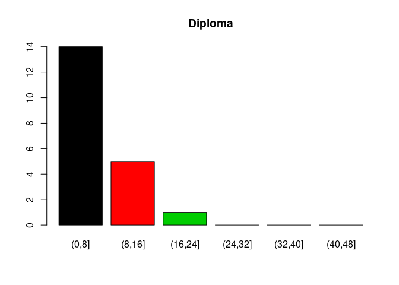

Da questo risultato capiamo che:

- La scelta di conseguire un titolo che attesti una qualifica professionale in Italia è generalmente poco seguita, la media nazionale è infatti del **6.8%**.
- La quasi totalità delle regioni centro-meridionali ha una percentuale **minore al 5.5%**, con alcune regioni come **Sicilia e Calabria** dove la percentuale raggiunge solo il **2%**.
- Nelle regioni del nord Italia invece le percentuali aumentano di molto e il caso del **Trentino-Alto Adige** è decisamente un unicum nel contesto italiano raggiungendo un valore percentuale addirittura 3 volte pari alla media nazionale con il **19.5%**.
- In generale al nord la qualifica professionale è molto più apprezzata e questo dato è in linea con gli studi sulle opportunità lavorative del territorio.

### Persone con maturità liceale

```r
table(cut(maturita,classiScelte))
```

```
##
##   (0,8]  (8,16] (16,24] (24,32] (32,40] (40,48]
##       0       0       0       3      14       3
```

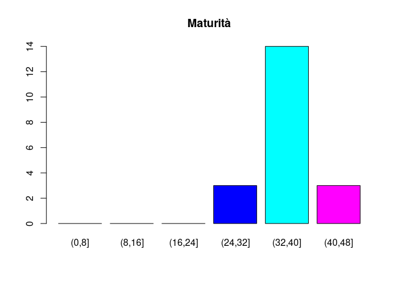

Da questo risultato capiamo che:

- Il dato sulla percentuale di persone che conseguono la maturità in Italia è piuttosto omogeneo in tutte le regioni e si attesta per ogni regione sulla media nazionale pari al **35.1%**.
- Il discostamento in positivo maggiore si ha in **Abruzzo, Umbria e Lazio** dove le prime due presentano una percentuale pari al **41.1%**, mentre il Lazio pari a **40.4%**.
- Il discostamento in negativo maggiore si ha in **Trentino-Alto Adige, Sardegna e Puglia** rispettivamente con **29.2%**, **30.8%** e **32%**.

### Persone con laurea o titolo avanzato

```r
table(cut(laurea,classiScelte))
```

```
##
##   (0,8]  (8,16] (16,24] (24,32] (32,40] (40,48]
##       0       4      15       1       0       0
```

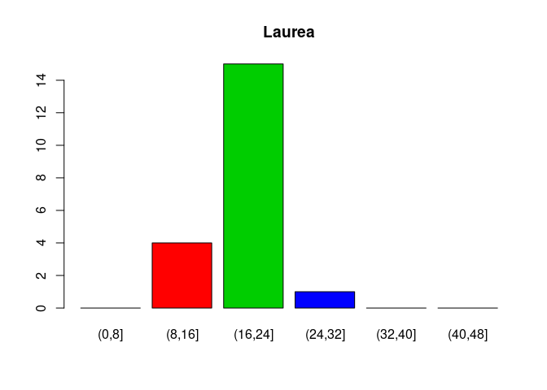

Da questo risultato capiamo che:

- Per questo ultimo dato risulta che le regioni italiane siano sostanzialmente spaccate ancora tra sud e il resto di Italia.
- Al sud infatti abbiamo la regione che ha il dato “peggiore”, cioè la **Sicilia** con una percentuale di laureati del **13.6%**, e anche le altre regioni del sud non vanno di molto oltre a questa percentuale.
- Sorprendentemente le regioni con le percentuali di laureati maggiori sono quelle del centro Italia e la regione che in assoluto si discosta maggiormente dalle altre è il **Lazio** con una percentuale che si distanzia del 6% dalla media nazionale con il suo **24.9%** di laureati.

## Distribuzione di frequenza relativa

Per calcolare le frequenze relative, invece, è necessario dividere l’output della frequenza assoluta per la lunghezza dei vettori presi in considerazione tramite la funzione lenght().  
Vediamo dunque quali percentuali otteniamo calcolando le frequenze relative dei titoli di studio per regione usando come scala la suddivisione in classi definita in precedenza.

### Persone con nessun titolo o licenza elementare

```r
table(cut(licenza_elementare_o_nessuno,classiScelte))/
      length(licenza_elementare_o_nessuno)
```

```
##
##   (0,8]  (8,16] (16,24] (24,32] (32,40] (40,48]
##     0.8     0.2     0.0     0.0     0.0     0.0
```

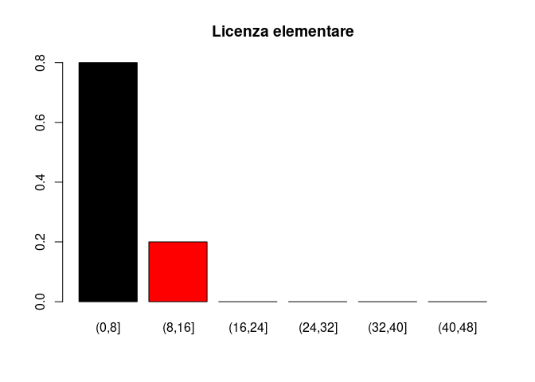

Da questo risultato capiamo che:

- L’**80%** delle regioni italiane presenta per la prima categoria una percentuale relativamente bassa.
- Il restante **20%** composto dalle regioni del sud già citate invece ha indici molto più alti e preoccupanti.

### Persone con licenza media

```r
table(cut(licenza_media,classiScelte))/length(licenza_media)
```

```
##
##   (0,8]  (8,16] (16,24] (24,32] (32,40] (40,48]
##    0.00    0.00    0.00    0.50    0.45    0.05
```

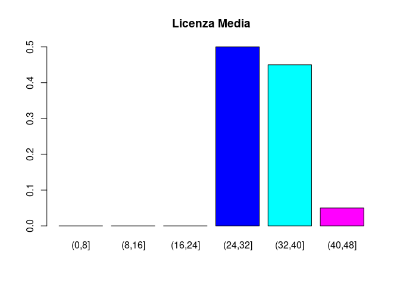

Da questo risultato capiamo che:

- Qui notiamo come il **50%** delle regioni presenta valori compresi tra il **24%** e il **32%**.
- Un altro **45%** sono regioni del centro-sud che hanno un valore leggermente più altro compreso tra il **32%** e il **40%**.
- Il restante **5%** è causato dalla **Sardegna** che presenta una percentuale altissima in questa categoria rispetto al resto delle regioni della penisola.

### Persone con diploma professionale

```r
table(cut(diploma,classiScelte))/length(diploma)
```

```
##
##   (0,8]  (8,16] (16,24] (24,32] (32,40] (40,48]
##    0.70    0.25    0.05    0.00    0.00    0.00
```

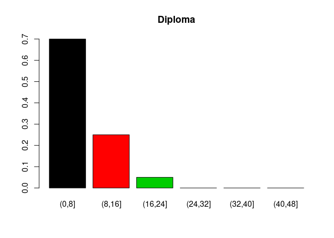

Da questo risultato capiamo che:

- Anche in questa categoria le percentuali sono abbastanza omogenee e il **70%** delle regioni ricade nella prima classe.
- Le restanti regioni tendono invece ad avere più individui nelle quali la scelta di conseguire un titolo professionale risulta maggiormente appetibile con il **25%**.
- L’unica regione che compone il restante **5%** è il **Trentino-Alto Adige** in cui il valore si distacca fortemente dalle altre regioni italiane e difatti è l’unica regione presenta nella terza classe selezionata.

### Persone con maturità

```r
table(cut(maturita,classiScelte))/length(maturita)
```

```
##
##   (0,8]  (8,16] (16,24] (24,32] (32,40] (40,48]
##    0.00    0.00    0.00    0.15    0.70    0.15
```

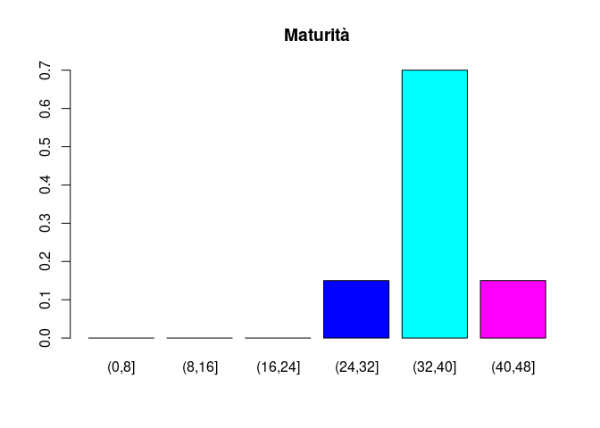

- Riguardo questa categoria abbiamo che la maggior parte delle regioni, il **70%**, ha una percentuale compresa tra il **32%** e il **40%**.
- Particolari sono alcune regioni nelle quali questi valori si distaccano o in positivo o in negativo suddividendo il restante **30%** in:
  - ci sono **Abruzzo, Umbria e Lazio** che hanno una percentuale molto alta e ricoprono con il **15%** l’ultima classe.
  - in modo opposto invece **Trentino-Alto Adige, Sardegna e Puglia** ricoprono con il **15%** del totale la classe relativa alle regioni con percentuali comprese tra **24% e 32%**

### Persone con laurea o titolo avanzato

```r
table(cut(laurea,classiScelte))/length(laurea)
```

```
##
##   (0,8]  (8,16] (16,24] (24,32] (32,40] (40,48]
##    0.00    0.20    0.75    0.05    0.00    0.00
```

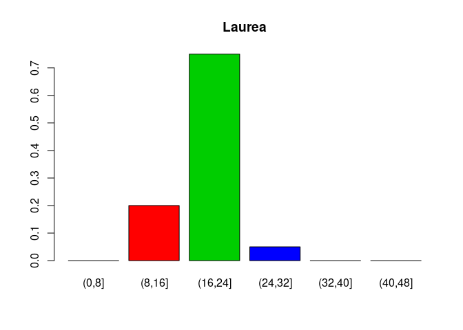

# Analisi tramite rappresentazioni grafiche

Le rappresentazioni grafiche sono necessarie in quanto ci permettono di avere una raffigurazione pulita dei dati che abbiamo. In poco spazio riusciamo a **visualizzare tanta conoscenza e a comunicarla in maniera più chiara ed efficace**.  
Infatti anche se la statistica produce i propri output in forma numerica o in tabelle, le tecniche grafiche ci permettono di comunicare al meglio i nostri risultati.  
Ci sono tantissimi tipologie di grafici attraverso cui esprimiamo il nostro lavoro di analisi. Vediamoli dunque nel dettaglio e arricchiamo la nostra conoscenza del dominio trattato.

## Grafici a barre

Attraverso i grafici a barre possiamo avere un quadro completo dei dati relativi alle categorie che analizziamo.  
Un grafico a barre è formato da una serie di barre della stessa larghezza, ognuna di esse descrive una categoria. L’altezza di ciascuna barra è proporzionale al valore riscontrato per ogni singola categoria presa in considerazione.  
Nel nostro caso le categorie sono le regioni e i valori riscontrati per ciascuna di esse sono le percentuali associate ai titoli di studio per regione.  
Per ciascuna delle colonne della matrice quindi andiamo a realizzare un grafico a barre in cui **sull’asse delle x avremo le regioni**, mentre **sull’asse delle y avremo le percentuali individuate per ogni tipologia di titolo di studio**.  
Con questa rappresentazione possiamo avere una visione d’insieme del dataset a disposizione.

In R per realizzare un grafico a barre si utilizza il comando barplot() con i parametri necessari per specificare i valori da rappresentare e la resa grafica.

- Grafico relativo alle persone con nessun titolo o licenza elementare

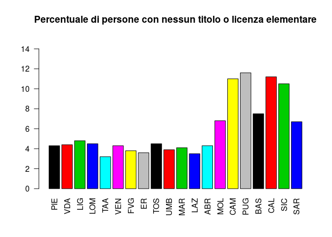

```r
barplot(matricePopolazionePerTitoloDiStudio[,1], col = 1:20,
    main = "Percentuale di persone con nessun titolo o licenza elementare",
    las=2, names.arg=regioniAbbreviate, ylim = c(0,15))
```

- Grafico relativo alle persone con licenza media

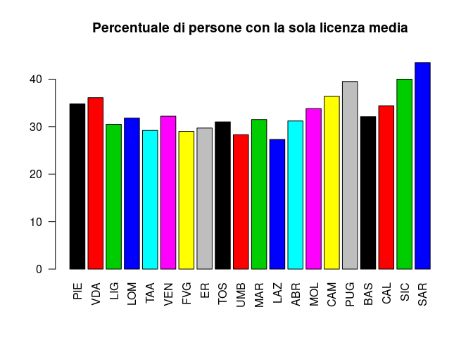

- Grafico relativo alle persone con diploma di qualifica professionale

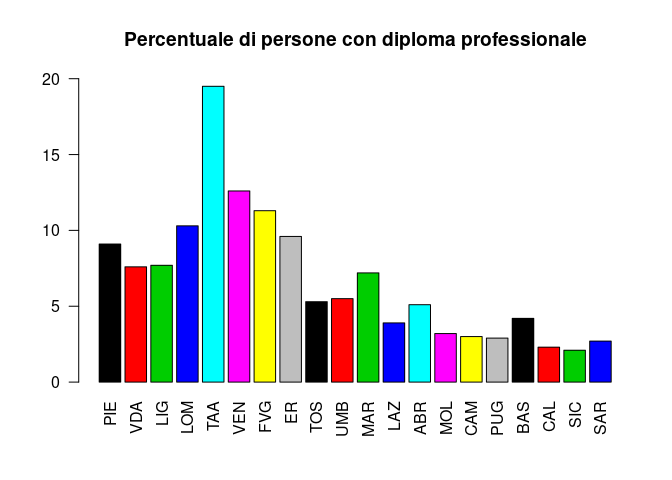

- Grafico relativo alle persone con maturità conseguita

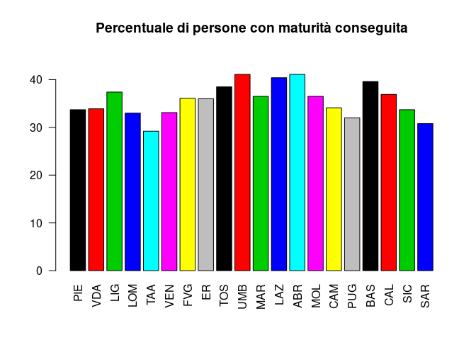

- Grafico relativo alle persone con laurea o titolo superiore conseguito

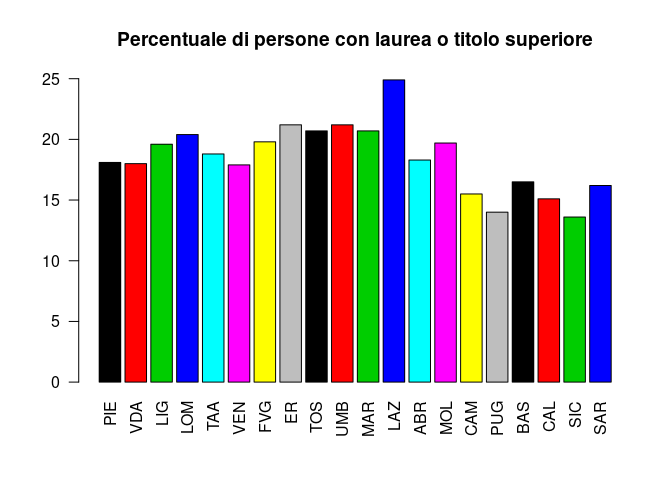

## Grafico a torta

Un grafico a torta è un grafico circolare suddiviso in “fette” che illustrano una porzione numerica. **L’arco descritto da ciascuna fetta è proporzionale alla quantità rappresentata**.  
Anche i grafici a torta consentono di avere una visione di insieme immediata, ma sono criticati da alcuni per la difficoltà di comparazione dei dati tra differenti grafici a torta.  
Possiamo usare un grafico a torta per riassumere la situazione italiana sui vari titoli di studio introducendo il vettore corrispondente alla situazione italiana ricavato dal dataset iniziale:

```r
italia <- c(
  rep("Scuola elementare/Nessun titolo",6.21),
  rep("Licenza media",33.3),
  rep("Diploma professionale",6.8),
  rep("Maturità",35.1),
  rep("Laurea/Post laurea",18.7)
  )
```

Disegnamo il grafico a torta con il comando pie() come mostrato nel seguente snippet:

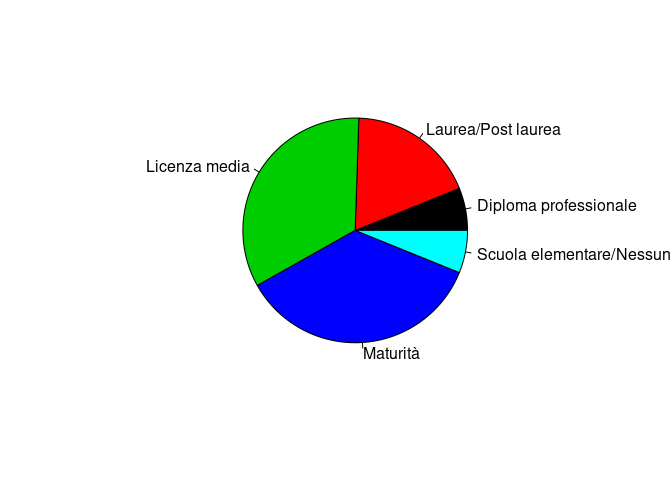

```r
pie(table(italia),col = 1:5)
```

## Plot per vettori

Attraverso la funzione plot possiamo visualizzare l’**andamento dei valori assunti** dai vari vettori che costituiscono la matrice che rappresenta il dataset. Consideriamo dunque ad uno ad uno i **vettori della nostra matrice** e vediamo come la funzione plot() ci permette di visualizzare le modalità assunte da ogni regione.

- Grafico relativo alle persone con nessun titolo o licenza elementare

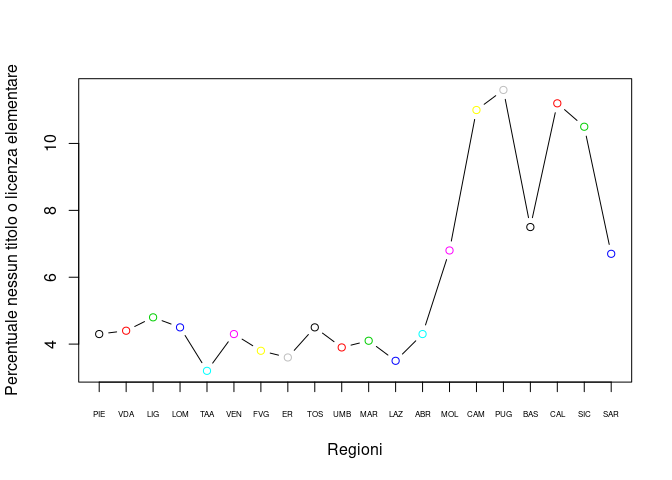

```r
plot(licenza_elementare_o_nessuno,
     ylab="Percentuale nessun titolo o licenza elementare",
     xlab="Regioni",
     col =1:20,type = "b",axes = FALSE)
box(which = "plot", lty = "solid")
axis(side=2)
axis(side=1, at=1:20, labels=regioniAbbreviate,cex.axis=0.50)
```

- Grafico relativo alle persone con licenza media

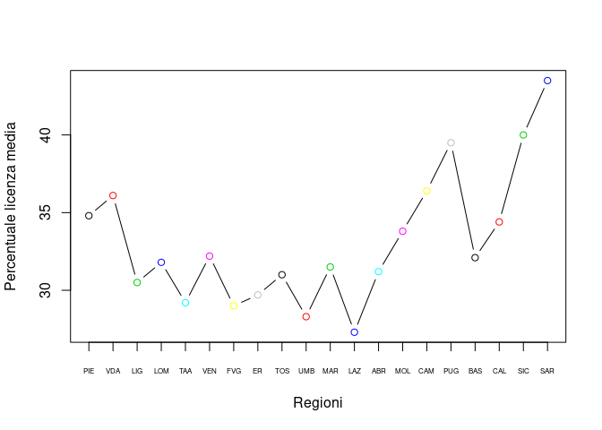

- Grafico relativo alle persone con diploma di qualifica professionale

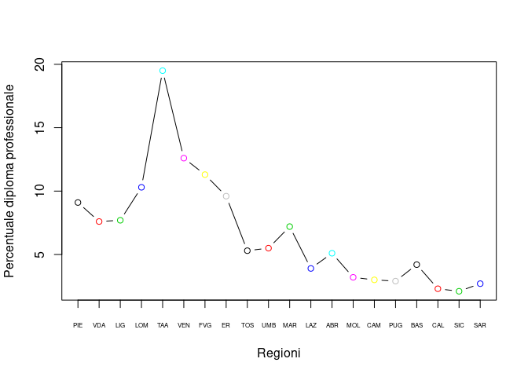

- Grafico relativo alle persone con maturità conseguita

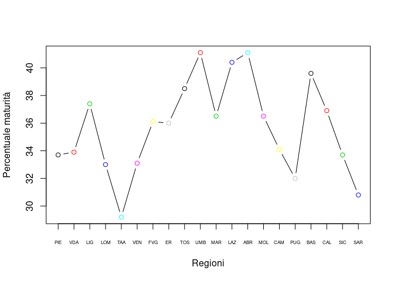

- Grafico relativo alle persone con laurea o titolo superiore conseguito

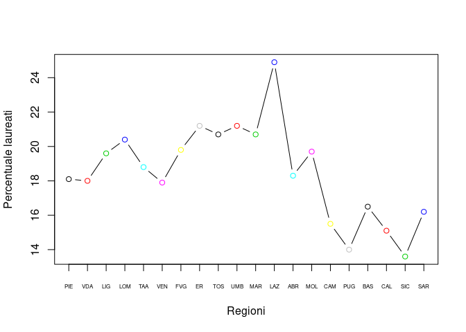

## Istogrammi

Un istogramma è un’altra rappresentazione della distribuzione di dati numerici. È un tipo di diagramma cartesiano usato quando l’intervallo di definizione delle variabili è diviso in sotto-intervalli di **ampiezza uguale o disuguale**. Quello che si ottiene da un istogramma è una figura costituita da una serie di rettangoli adiacenti aventi la base sull’asse delle ascisse e di altezza dipendente dalla frequenza delle classi.  
Per costruire un istogramma il primo passo è quello di dividere il range dei valori assunti in una serie di intervalli e successivamente bisogna contare quanti valori cadono in ogni intervallo. I “contenitori” utilizzati sono solitamente specificati come intervalli di variabili consecutivi e non sovrapposti.

In R utilizziamo la funzione hist() per disegnare un istogramma. Il numero di classi può essere definito dall’utente, ma può anche essere **lasciato a discrezione di R che deciderà il numero di classi che ritiene adeguato**.  
La funzione hist genera oltre al grafico anche altre informazioni utili: i **breaks** definiti per la creazione dell’istogramma, le **frequenze assolute** delle classi, la **densità** delle classi e i **punti centrali** delle classi.

Vediamo ad esempio l’istogramma relativo alla percentuale di laureati:

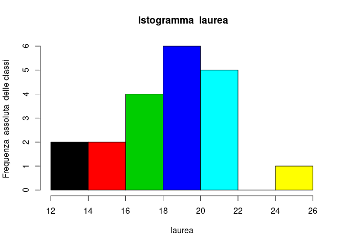

```r
laureaHistOutput<-hist(laurea ,freq=TRUE ,main=" Istogramma  laurea",
                 ylab="Frequenza  assoluta  delle classi ",col = 1:7)
```

```r
str(laureaHistOutput)
```

```
## List of 6
##  $ breaks  : int [1:8] 12 14 16 18 20 22 24 26
##  $ counts  : int [1:7] 2 2 4 6 5 0 1
##  $ density : num [1:7] 0.05 0.05 0.1 0.15 0.125 0 0.025
##  $ mids    : num [1:7] 13 15 17 19 21 23 25
##  $ xname   : chr "laurea"
##  $ equidist: logi TRUE
##  - attr(*, "class")= chr "histogram"
```

```r
laureaHistOutput$breaks
```

```
## [1] 12 14 16 18 20 22 24 26
```

```r
laureaHistOutput$counts
```

```
## [1] 2 2 4 6 5 0 1
```

```r
laureaHistOutput$density
```

```
## [1] 0.050 0.050 0.100 0.150 0.125 0.000 0.025
```

```r
laureaHistOutput$mids
```

```
## [1] 13 15 17 19 21 23 25
```

La suddivisione in classi fatta da R ha restituito le seguenti **sette classi**: (12,14] (14,16] (16,18] (18,20] (20,22] (22,24] (24,26].  
Infatti, dei 20 valori, 2 cadono nella prima, 2 nella seconda, 4 nella terza, 6 nella quarta, 5 nella quinta, 0 nella sesta e 1 nell’ultimo.  
Le frequenze relative associate alle sette classi possono essere ottenute moltiplicando gli elementi del vettore dell’attributo density per l’ampiezza delle classi che nel nostro caso è 2.

```r
laureaHistOutput$density * 2
```

```
## [1] 0.10 0.10 0.20 0.30 0.25 0.00 0.05
```

Il parametro freq ci permette di specificare se calcolare le frequenze assolute o relative di ogni classe.

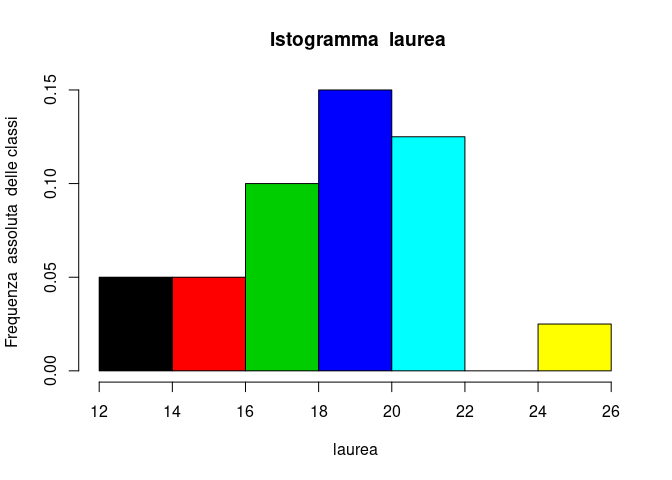

```r
laureaHistOutputRel<-hist(laurea ,freq=FALSE ,main=" Istogramma  laurea",
                 ylab="Frequenza  assoluta  delle classi ",col = 1:7)
```

```r
str(laureaHistOutput)
```

```
## List of 6
##  $ breaks  : int [1:8] 12 14 16 18 20 22 24 26
##  $ counts  : int [1:7] 2 2 4 6 5 0 1
##  $ density : num [1:7] 0.05 0.05 0.1 0.15 0.125 0 0.025
##  $ mids    : num [1:7] 13 15 17 19 21 23 25
##  $ xname   : chr "laurea"
##  $ equidist: logi TRUE
##  - attr(*, "class")= chr "histogram"
```

```r
laureaHistOutputRel$breaks
```

```
## [1] 12 14 16 18 20 22 24 26
```

```r
laureaHistOutputRel$counts
```

```
## [1] 2 2 4 6 5 0 1
```

```r
laureaHistOutputRel$density
```

```
## [1] 0.050 0.050 0.100 0.150 0.125 0.000 0.025
```

```r
laureaHistOutputRel$mids
```

```
## [1] 13 15 17 19 21 23 25
```

Il codice produce l’istogramma rappresentato in base alle densità di frequenza delle classi. Anche qui il numero di classi è stato scelto da R.  
Anche in questo caso la funzione hist() restituisce un elemento di tipo lista con gli stessi attributi del caso in cui viene considerata la frequenza assoluta.

Anche per ottenere le frequenze relative il procedimento è analogo al precedente.

## Boxplot

Nella statistica descrittiva un boxplot è un metodo per raffigurare graficamente gruppi di dati numerici attraverso i **quartili**.  
Quando parliamo di quartili si intende un **particolare tipo di quantile**. Il primo quartile, indicato generalmente con **Q1**, è definito come il valore centrale più piccolo tra il numero più piccolo e la mediana: il valore per il quale si trovano il **25% dei valori più piccoli alla propria sinistra e il 75% dei valori più grandi alla sua destra**.  
Il secondo quartile (**Q2**) è la mediana dei dati: ha il **50% dei dati più piccoli alla sinistra e il restante 50% dei valori più grandi alla destra**.  
Il terzo quartile (**Q3**) è il valore centrale tra la mediana e il valore più grande del dataset.  
**Q0** e **Q4** sono invece rispettivamente il valore minimo e il valore massimo del campione.  
I quartili si calcolo tramite la funzione quantile() in R, mentre la funzione summary() restituisce i valori precisi dei quartili.  
Vediamo ad esempio per il vettore contente le informazioni sulla percentuale di individui con nessun titolo o la licenza elementare quale output ci viene fornito:

```r
quantile(licenza_elementare_o_nessuno)
```

```
##     0%    25%    50%    75%   100%
##  3.200  4.050  4.450  6.975 11.600
```

Da cui deduciamo che Q0 = 3.2, Q1 = 4.050, Q2 = 4.450, Q3 = 6.975 e Q4 = 11.600.

```r
summary(licenza_elementare_o_nessuno)
```

```
##    Min. 1st Qu.  Median    Mean 3rd Qu.    Max.
##   3.200   4.050   4.450   5.925   6.975  11.600
```

- Nessun titolo o scuola elementare

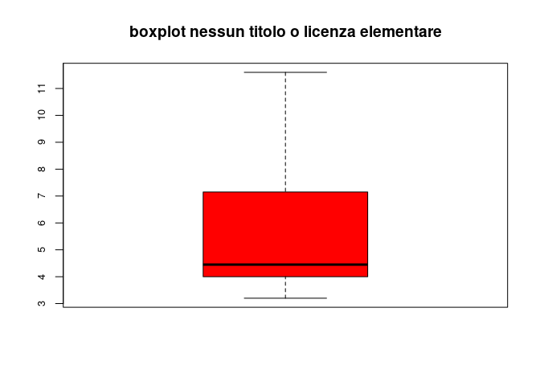

```r
boxplot(licenza_elementare_o_nessuno,
        main = "boxplot nessun titolo o licenza elementare",
        col = "red", axes = FALSE)
axis(side=2, 3:12, cex.axis=0.80)
box()
```

```r
summary(licenza_elementare_o_nessuno)
```

```
##    Min. 1st Qu.  Median    Mean 3rd Qu.    Max.
##   3.200   4.050   4.450   5.925   6.975  11.600
```

Da cui deduciamo che Q0 = 3.2, Q1 = 4.050, Q2 = 4.450, Q3 = 6.975 e Q4 = 11.600.

Per avere le informazioni relative all’esecuzione della funzione boxplot sul vettore possiamo usare boxplot.stats() che restituisce un dataframe contenente tra le varie cose un vettore di lunghezza cinque con i valori dei baffi e di Q1, Q2 e Q3, e ci **dà anche informazioni riguardo eventuali valori che si trovano al di fuori dei baffi**:

```r
elementariBoxPlotStats <- boxplot.stats(licenza_elementare_o_nessuno)
#Baffo inferiore
elementariBoxPlotStats$stats[1]
```

```
## [1] 3.2
```

```r
#Baffo superiore
elementariBoxPlotStats$stats[5]
```

```
## [1] 11.6
```

```r
#valori anomali
elementariBoxPlotStats$out
```

```
## numeric(0)
```

Il baffo inferiore è quindi pari a 3.2, cioè il minimo dei valori del vettore.  
Il baffo superiore è pari a 11.6 e corrisponde al massimo: **non ci sono dunque valori anomali poiché ogni valore è compreso tra i due baffi**.  
Il grafico infatti non ci indica la presenza valori anomali.  
Possiamo anche affermare che c’è una **forte asimmetria dei dati** dato che la differenza Q3 – Q2 è molto più grande rispetto a quella tra Q2 – Q1. Questa deduzione è chiara anche solo visualizzando il grafico poiché la mediana è praticamente prossima alla base inferiore della scatola.

- Licenza media

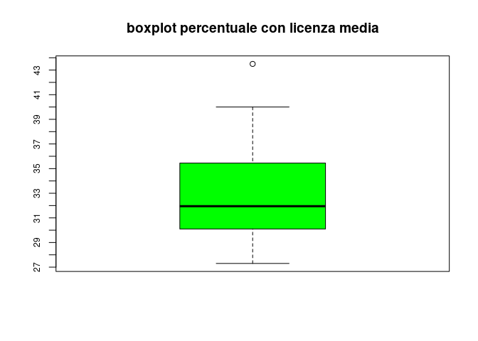

```
##    Min. 1st Qu.  Median    Mean 3rd Qu.    Max.
##   27.30   30.30   31.95   33.12   35.12   43.50
```

Quindi **Q0 = 27.30, Q1 = 30.30, Q2 = 31.95, Q3 = 35.12 e Q4 = 43.50**.

```
## [1] 27.3
```

```
## [1] 40
```

Il baffo inferiore è quindi pari a 27.3, cioè il minimo dei valori del vettore.  
Il baffo superiore è invece pari a 40.0 e non corrisponde al massimo: **c’è un valore anomalo**.

```r
mediaBoxPlotStats$out
```

```
## [1] 43.5
```

Il grafico infatti indica la presenza di un valore anomalo ed è corrispondente a quello della **Sardegna** che è infatti pari a 43.5, cioè maggiore del baffo superiore.

Anche per questa categoria abbiamo un’**asimmetria dei dati**, meno marcata rispetto al caso precedente ma è comunque evidente anche con un’analisi visuale che la differenza Q3 – Q2 è maggiore rispetto alla a quella tra Q2 – Q1. Questa deduzione è chiara anche solo visualizzando il grafico poiché la mediana è praticamente prossima alla base inferiore della scatola.

- Diploma professionale

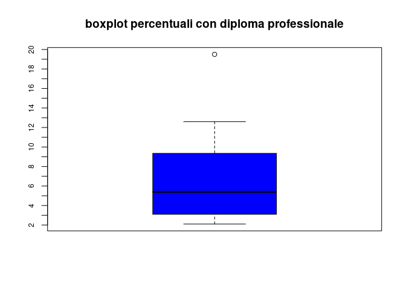

```
##    Min. 1st Qu.  Median    Mean 3rd Qu.    Max.
##   2.100   3.150   5.400   6.755   9.225  19.500
```

Quindi **Q0 = 2.1, Q1 = 3.15, Q2 = 5.4, Q3 = 9.225 e Q4 = 19.5**.

```
## [1] 2.1
```

```
## [1] 12.6
```

Il baffo inferiore è quindi pari a 2.1, cioè il minimo dei valori del vettore.  
Il baffo superiore è invece pari a 12.6 e non corrisponde al massimo: **c’è un valore anomalo**.

```r
diplomaBoxPlotStats$out
```

```
## [1] 19.5
```

Il grafico infatti indica la presenza di un valore anomalo ed è corrispondente a quello del **Trentino-Alto Adige** che è infatti pari a 19.5 come indicatoci da R, e cioè maggiore del baffo superiore.

Come nel caso precedente anche qui vi è **asimmetria nei dati** abbastanza marcata.

- Maturità

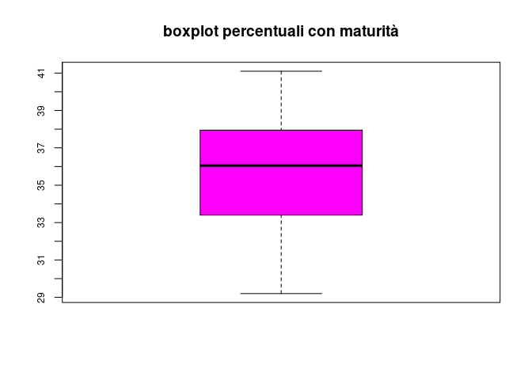

```
##    Min. 1st Qu.  Median    Mean 3rd Qu.    Max.
##   29.20   33.55   36.05   35.68   37.67   41.10
```

Quindi **Q0 = 29.20 Q1 = 33.55 Q2 = 36.05 Q3 = 37.67 Q4 = 41.10**

```
## [1] 29.2
```

```
## [1] 41.1
```

Il baffo inferiore è quindi pari a 29.2, cioè il minimo dei valori del vettore.  
Il baffo superiore è invece pari a 41.1, cioè il massimo: **non ci sono valori anomali**1.

Anche in questo vettore abbiamo una discreta **asimmetria nei dati**, ma a differenza dei casi precedenti la mediana è più vicina a Q3.

- Laurea

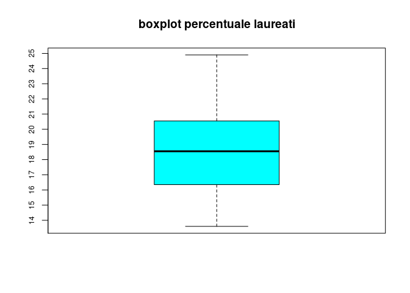

```
##    Min. 1st Qu.  Median    Mean 3rd Qu.    Max.
##   13.60   16.43   18.55   18.51   20.48   24.90
```

Quindi **Q0 = 13.60, Q1 = 16.43, Q2 = 18.55, Q3 = 20.48, Q4 = 24.90**

```
## [1] 13.6
```

```
## [1] 24.9
```

Il baffo inferiore è quindi pari a 13.6, cioè il minimo dei valori del vettore.  
Il baffo superiore è invece pari a 24.9, cioè il massimo: non ci sono valori anomali.

In questo caso i valori del vettore sono abbastanza **simmetrici** infatti la mediana è solo leggermente più vicina a Q3.

- Confronto tra boxplot

Tra le varie possibilità che ci dà R c’è anche quella di confrontare i vari Boxplot inserendoli in un unico grafico in modo da avere un quadro completo:

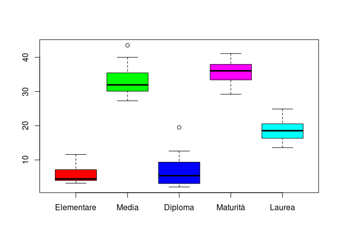

```r
boxplot(licenza_elementare_o_nessuno, licenza_media, diploma, maturita, laurea,
        col = c("red","green","blue","magenta", "cyan"),
        names = c("Elementare", "Media", "Diploma", "Maturità", "Laurea"))
```

Riguardo l’analisi tramite Boxplot quindi siamo venuti a conoscenza di una **tendente asimmetria delle colonne del nostro dataset**: la prima categoria è quella che presenta una asimmetria maggiore, mentre l’ultima è quella maggiormente simmetrica.  
Siamo venuti inoltre a conoscenza di **due valori anomali** nella seconda e nella terza categoria in corrispondenza della percentuale di individui con la licenza media in **Sardegna** e per la percentuale di individui con un diploma professionale in **Trentino-Alto Adige**.

## Grafico di dispersione

Un grafico di dispersione, anche chiamato **scatterplot**, è un tipo di diagramma che utilizza coordinate cartesiane per mostrare tipicamente due variabili di un dato set. I dati vengono definiti come una collezione di punti, ognuno dei quali prende valore rispetto all’asse orizzontale o quello verticale in base all’insieme di appartenenza. La variabile posta sull’asse delle ascisse viene definita **variabile indipendente**, mentre quella posta sull’asse delle ordinate viene chiamata **variabile dipendente**.  
Il risultato grafico di un diagramma di dispersione è quello di avere una **nuvola di punti**: questo tipo di rappresentazione serve a capire **se esiste una relazione tra le variabili e di che tipo si tratta**.  
In R uno scatterplot di due vettori viene definito tramite il comando plot(vettore1, vettore2).

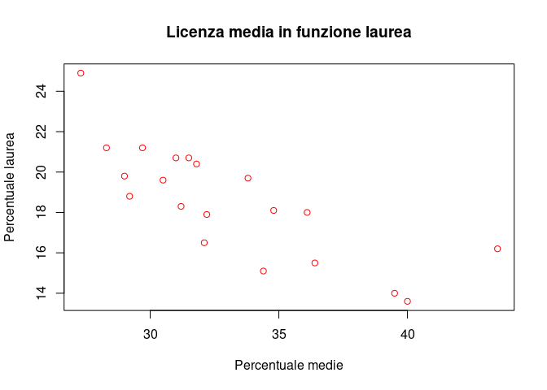

```r
plot(licenza_media,laurea,
main = "Licenza media in funzione laurea",
xlab = "Percentuale medie", ylab = "Percentuale laurea", col ="red")
```

Un’altra possibilità che ci dà R è quella di visualizzare un grafico contenente uno **scatterplot per ogni coppia di variabili** del nostro dataset. Per farlo ci basta semplicemente utilizzare la funzione pairs() e passare la matrice della nostra popolazione: in un unico grafico abbiamo **tutti gli scatterplot mettendo in relazione tutte le possibili coppie**.  
Vediamo dunque questo tipo di grafico:

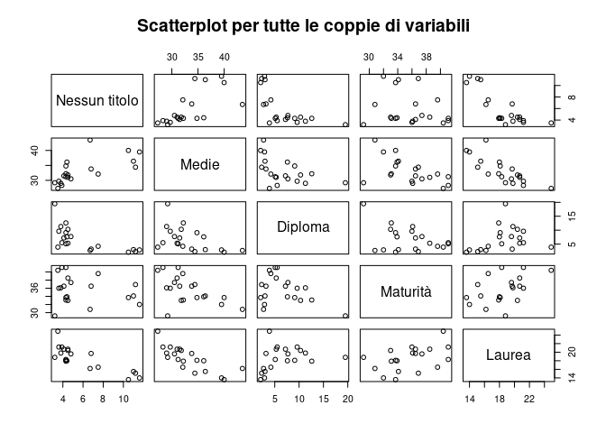

```r
pairs(matricePopolazionePerTitoloDiStudio,
      main = "Scatterplot per tutte le coppie di variabili")
```

I vari grafici ottenuti mostrano le nuvole di punti che si ottengono prendendo in considerazioni tutte le differenti coppie di variabili.  
Nei successivi capitoli analizzeremo i due vettori usati in precedenza per valutare se esiste una qualche relazione e se esiste una qualche retta o curva che interpola i punti.

# Statistica descrittiva

La statistica **descrittiva** è una statistica di sintesi che descrive **quantitativamente** e **sintetizza** le caratteristiche di una collezione di dati.  
La statistica descrittiva si distingue dalla statistica **inferenziale** (o induttiva), in quanto quella descrittiva ha come proprio scopo quello di sintetizzare un campione con **pochi numeri o grafici significativi**, cioè si occupa di **fotografare una data situazione e di sintetizzarne le caratteristiche salienti**, mentre quella inferenziale si concentra piuttosto sull’utilizzo dei dati statistici, anche sintetizzati mediante la statistica descrittiva, per fare **previsioni probabilistiche**. La statistica descrittiva non si sviluppa sulle basi della teoria della probabilità e sono statistiche non parametriche.

Alcune misure che sono comunemente utilizzate per descrivere un insieme di dati sono le **misure di centralità** e le **misure di dispersione o variabilità**.  
Del primo gruppo fanno parte la **media campionaria, la mediana e la moda**, mentre misure di variabilità includono **la varianza, la deviazione standard, la curtosi campionaria e la skewness campionaria**.  
La statistica descrittiva fornisce semplici misure di sintesi sul campione e sulle osservazioni che sono state fatte. Queste sintesi possono essere quantitative o visuali e possono essere sia la base di un’iniziale descrizione dei dati come parte di un’analisi più approfondita, ma anche sufficienti da soli per particolari indagini.

Vediamo dunque la statistica descrittiva **univariata** in primo luogo e successivamente la statistica descrittiva **bivariata**.

## Statistica descrittiva Univariata

La statistica descrittiva **univariata** descrive la distribuzione di una **singola variabile** e include gli indici di posizione **centrali** (**media, mediana, moda**) e **non centrali** (**quantili**: quartili, decili, percentali) e gli indici di dispersione (**varianza, deviazione standard, coefficiente di variazione**) che misurano quanto si disperdono i dati rispetto alla media.  
Descriviamo la **forma** della distribuzione invece attraverso gli indici di **skewness e curtosi**.  
Nel corso della trattazione dei vari indici di sintesi, questi saranno accompagnati con opportuni grafici.

### Funzione di distribuzione empirica

Quando abbiamo a che fare con fenomeni quantitativi, come nel nostro caso, è utile definire la **funzione di distribuzione empirica**.  
Vediamo quindi la funzione di distribuzione empirica **discreta** e successivamente quella **continua**.

#### Funzione di distribuzione empirica discreta

La funzione viene definita a partire dalle **frequenze relative cumulate**.  
Prendiamo in considerazione una delle nostre variabili quantitative come ad esempio la percentuale di individui che hanno conseguito una laurea per ogni regione. Diciamo che i **valori distinti che può assumere questa variabile** sono z1,z2 … zk e assumiamo che siano ordinati in **ordine crescente**. Consideriamo poi le frequenze relative e le **frequenze relative cumulate**:

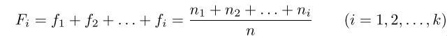

dove la generica $F_i$ rappresenta la proporzione dei dati del campione minori o uguali di zi. Una funzione di distribuzione empirica discreta risulta:

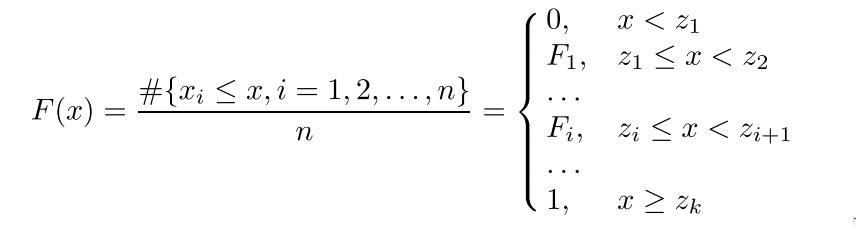

La funzione è definita per ogni x reale e ha diverse caratteristiche:

- È una funzione **a scalini non decrescente**
- In corrispondenza di ogni salto assume il valore a sinistra sull’asse delle ascisse
- La funzione vale:
  - **0** per ogni valore minore dell’osservazione minima
  - **1** per ogni valore maggiore dell’osservazione massima

R mette a disposizione la funzione ecdf() (**empirical cumulative distribution function**) che ci permette di disegnare il grafico della funzione e di determinare per ogni x reale il valore di tale funzione.

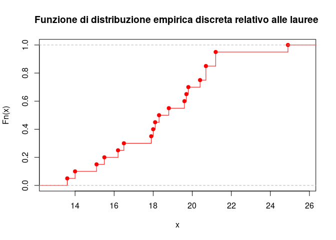

```r
plot(
  ecdf(laurea),
  main="Funzione di distribuzione empirica discreta relativo alle lauree ",
  verticals = TRUE , col="red")
```

Nel caso si voglia sapere il valore della funzione in un dato punto x, R permette di farlo nel seguente modo:

```r
ecdf(laurea)(17)
```

```
## [1] 0.3
```

#### Funzione di distribuzione empirica continua

La funzione di distribuzione empirica continua viene invece utilizzata quando si lavora con **dati raccolti in classi**. Infatti considerando la tipologia del nostro campione di dati è più opportuno suddividere le informazioni a disposizione in k distinte classi. Anche in questo caso la funzione viene definita a partire dalle **frequenze relative cumulate**.

La funzione di distribuzione empirica continua è dunque così definita:

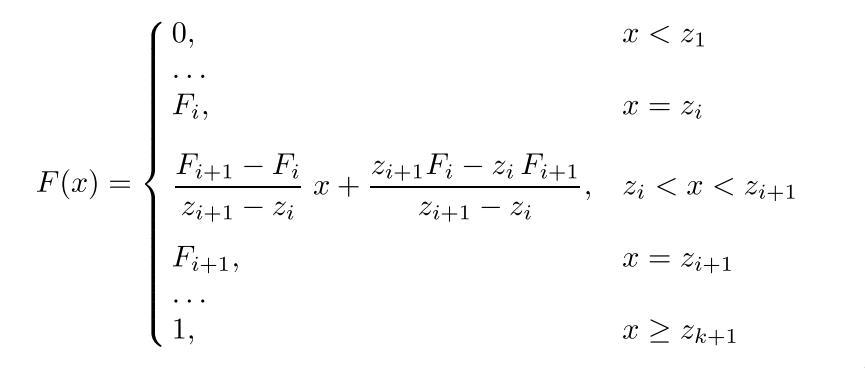

La funzione è definita per ogni x reale e:

- Vale **0** per ogni x minore di z1
- Vale **1** per ogni x maggiore o uguale a zk+1
- Se **zi < x < zi+1** coincide con il segmento che passa per i punti (zi, Fi) e (zi+1,Fi+1)

Introduciamo dunque le seguenti classi:  
**[0,5) [5,10) [10,15) [15,20) [20,25) [25,30) [30,35) [35,40) [40,45) [45,50)**

```r
classiDistrEmpCont <-c(0, 5, 10, 15, 20, 25, 30, 35, 40, 45, 50)
```

Descriviamo ora come ottenere il grafico della funzione di distribuzione empirica continua per quanto riguarda la licenza elementare:

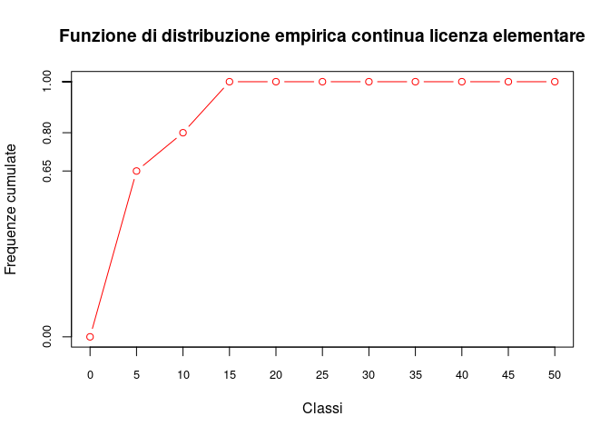

```r
FrequenzaCumulateLicEle <- cumsum (table (
  cut(licenza_elementare_o_nessuno ,
  breaks =classiDistrEmpCont ,
  right =FALSE )))/length (licenza_elementare_o_nessuno)

FrequenzaCumulateLicEle <- c(0,FrequenzaCumulateLicEle)
plot(classiDistrEmpCont ,
     FrequenzaCumulateLicEle , type = "b", axes = FALSE ,
     main = "Funzione di distribuzione empirica continua licenza elementare",
     col="red", xlab = "Classi", ylab = "Frequenze cumulate")
axis(1, classiDistrEmpCont, cex.axis=0.80)
axis(2, format (FrequenzaCumulateLicEle , digits = 2), cex.axis=0.80)
box ()
```

Procediamo con i grafici per ogni altra variabile.

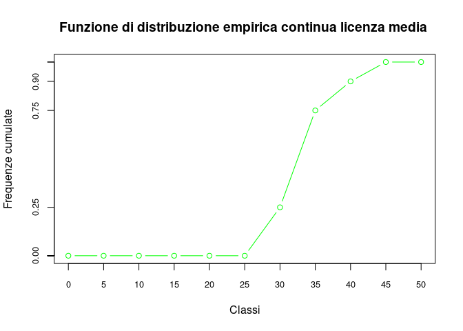

I dati sono concentrati principalmente verso le ultime classi, i primi valori si riscontrano nella classe [25,30). In generale abbiamo percentuali mediamente molto alte.

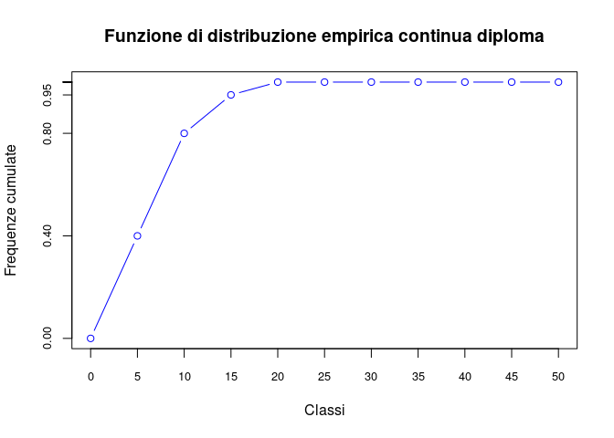

Analogamente alla prima situazione anche qui l’unità si raggiunge subito e c’è una concentrazione di dati nelle prime classi: addirittura con le prime due classi copriamo **l’80%** dei dati.

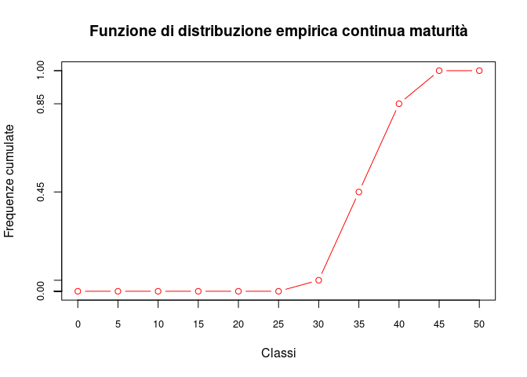

I dati sono concentrati principalmente verso le ultime classi, le percentuali sono **mediamente molto alte**.

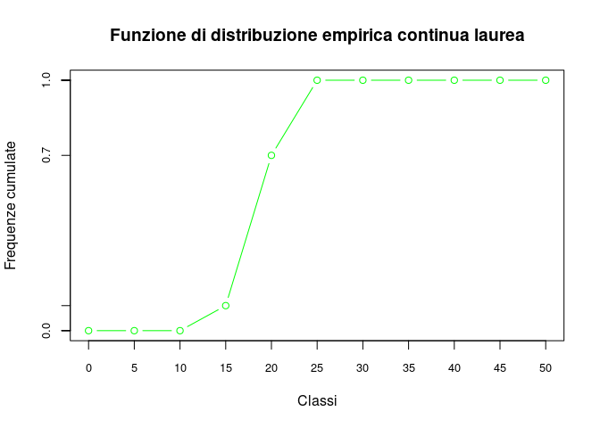

Il grafico si differenzia dagli altri per raggiungere l’unità nelle classi centrali, i dati sono **molto più centrati rispetto agli altri** dove abbiamo visto una concentrazione nelle classi iniziali e quelle finali, qui invece la **concentrazione è in quelle centrali**.

### Indici di sintesi

Gli indici di sintesi sono necessari per **sintetizzare e classificare specifiche osservazioni** sui dati che abbiamo.  
Per avere una visione d’insieme dei nostri dati e ricavare informazioni quanto più complete possibili è preferibile che gli **indici di sintesi vadano osservati assieme**.

Vediamo dunque attraverso i boxplot dei nostri vettori quali sono le caratteristiche delle loro distribuzioni di frequenza: possiamo comprenderne la **forma e se i dati risultano molto variabili o meno**.

Nel seguente grafico riportiamo tutti i boxplot osservati:

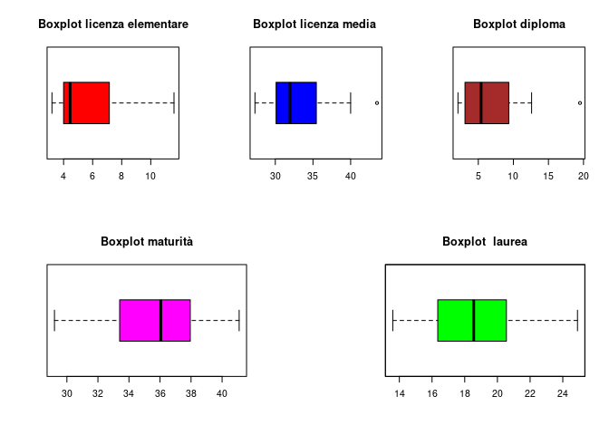

In tutti i grafici notiamo una certa asimmetria: la più marcata è nel primo boxplot relativo alla percentuale della licenza elementare, mentre quello più regolare sembra essere quello relativo alle lauree.

Gli indici che introdurremo nel seguito servono a misurare quantitativamente alcune delle caratteristiche che si possono intuire nei grafici delle distribuzioni di frequenza e nei box plot.

#### Media campionaria

Supponiamo di avere un campione di numerosità N con valori x1,x2 … xn.  
Definiamo la media campionaria come la **media aritmetica** di questi valori:

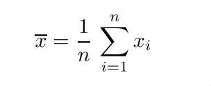

La media campionaria ha diverse proprietà:

- Gode della **proprietà di linearità**:

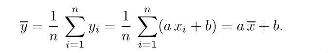

- È una **media pesata dei valori distinti assunti** dai dati dove ogni valore distinto usa come peso la **frequenza**:

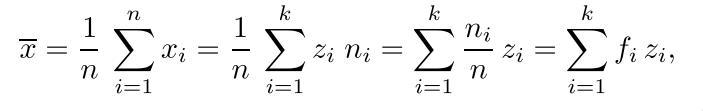

- La somma algebrica degli scarti della media campionaria è sempre **nulla**:

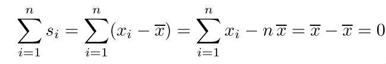

- La media è **influenzata da tutti i dati** e in particolar modo da valori particolarmente grandi o piccoli, cioè da **valori anomali**

R ci mette a disposizione la funzione mean() per calcolare la media campionaria dei nostri dati.  
Applichiamo questa funzione ad ogni vettore che compone il nostro campione:

```r
mediaCampionariaElementari <- mean(licenza_elementare_o_nessuno)
mediaCampionariaElementari
```

```
## [1] 5.925
```

```r
mediaCampionariaMedie <- mean(licenza_media)
mediaCampionariaMedie
```

```
## [1] 33.115
```

```r
mediaCampionariaDiploma <- mean(diploma)
mediaCampionariaDiploma
```

```
## [1] 6.755
```

```r
mediaCampionariaMaturita <- mean(maturita)
mediaCampionariaMaturita
```

```
## [1] 35.68
```

```r
mediaCampionariaLaurea <- mean(laurea)
mediaCampionariaLaurea
```

```
## [1] 18.51
```

#### Mediana campionaria

Un altro indice di posizione è la **mediana**.  
Data una distribuzione di un carattere quantitativo oppure qualitativo ordinabile si definisce mediana (o valore mediano) il **valore che separa la metà più grande e la metà più piccola di un campione di dati**, cioè il valore che si trova **nel mezzo della distribuzione**.

I passi per calcolare la mediana sono i seguenti:

- Si ordinano gli n elementi in **ordine crescente**
- Se il numero di dati è **dispari** la mediana corrisponde al valore $\frac{n+1}{2}$
- Se il numero di dati è **pari** allora la mediana è calcolato come la media aritmetica dei valori alla posizione $\frac{n}{2}$ e alla posizione $\frac{n}{2}+1$

È importante notare come la mediana campionaria **dipenda solo da uno o due valori** e quindi **non risente degli estremi**.

In R per calcolare la mediana abbiamo a disposizione la funzione median().  
Calcoliamola dunque per i nostri vettori:

```r
medianaElementari <- median(licenza_elementare_o_nessuno)
medianaElementari
```

```
## [1] 4.45
```

```r
medianaMedie <- median(licenza_media)
medianaMedie
```

```
## [1] 31.95
```

```r
medianaDiploma <- median(diploma)
medianaDiploma
```

```
## [1] 5.4
```

```r
medianaMaturita <- median(maturita)
medianaMaturita
```

```
## [1] 36.05
```

```r
medianaLaurea <- median(laurea)
medianaLaurea
```

```
## [1] 18.55
```

Visualizziamo in forma tabellare i risultati:

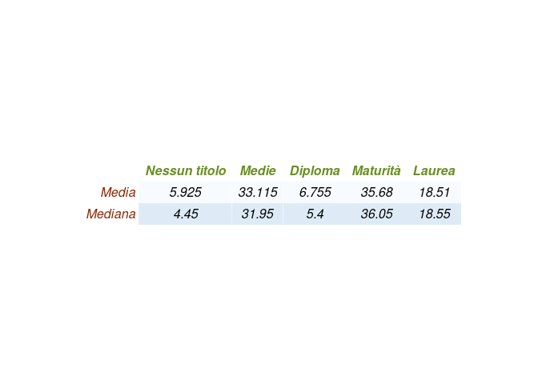

Dalla tabella notiamo che il calcolo della media e della mediana ha **prodotto risultati simili per ciascuna categoria**, ad esempio il vettore laurea dà praticamente lo stesso risultato per media e mediana, mentre per la prima variabile vediamo la differenza maggiore.  
Confrontare media e mediana è utile poiché se queste misure sono simili, come nel nostro caso, la **distribuzione di frequenza tende ad essere simmetrica**.  
Vedremo nel paragrafo in cui studiamo la forma della distribuzione se questa intuizione sarà verificata.

##### Mediana per una distribuzione di frequenza

La mediana di una distribuzione di frequenza può essere individuata graficamente a partire dalla funzione di distribuzione empirica discreta continua, ad esempio:

[figure not shown]

#### Moda campionaria

La moda identifica la **modalità che si presenta con la maggiore frequenza** (assoluta o relativa) in un campione. Se ci sono più modalità con frequenza massima, ciascuna viene definita come **valore modale**.  
Sulla moda c’è da dire che questa, a differenza di media e mediana, **può essere calcolata anche quando si ha a che fare con dati di tipo qualitativo**.  
Nel nostro caso è **inutile calcolarla** in quanto abbiamo a che fare con percentuali.

Infine sottolineiamo che media, mediana e moda sono detti indici di posizione centrale poiché **descrivono attorno a quali valori è centrato l’insieme di dati**.

#### Quantili

Sono definiti come indici di sintesi di posizione non centrali.  
I quantili **dividono l’insieme dei dati in un fissato numero di parti uguali**.  
Definiamo i quantili in base a come viene suddiviso l’insieme dei dati:

- Se l’insieme dei dati viene suddiviso in 100 parti mediante 99 quantili si parla di **percentili**
- Se l’insieme dei dati viene suddiviso in 10 parti mediante 9 quantili si parla di **decili**
- Se l’insieme dei dati viene suddiviso in 4 parti mediante 3 quantili si parla di **quartili**

Ovviamente sia quartili che decili sono un caso particolare dei percentili.

In R esistono 9 algoritmi per calcolare i quantili utilizzando la funzione quantile() e specificando il parametro type con un numero nell’insieme {1 … 9}. R utilizza di default l’algoritmo di tipo 7. Ad ogni modo **se il numero di osservazioni è elevato, i valori calcolati dagli algoritmi tendono a coincidere**.

I percentili maggiormente utilizzati sono il 25-esimo, il 50-esimo e il 75-esimo detti rispettivamente **primo quartile (Q1), secondo quartile (Q2), terzo quartile (Q3)**.

Vediamo dunque il calcolo dei quartili per il vettore laurea come cambia anche in base al tipo di algoritmo scelto:

```r
quantile(laurea)
```

```
##     0%    25%    50%    75%   100%
## 13.600 16.425 18.550 20.475 24.900
```

```r
quantile(laurea, type = 2)
```

```
##    0%   25%   50%   75%  100%
## 13.60 16.35 18.55 20.55 24.90
```

```r
quantile(laurea, type = 1)
```

```
##   0%  25%  50%  75% 100%
## 13.6 16.2 18.3 20.4 24.9
```

#### Varianza e deviazione standard campionaria

Gli indici di posizione sono importanti, ma le informazioni che ci danno non tengono conto della **variabilità dei dati**: può capitare di avere a che fare con distribuzioni di frequenza molto diverse tra di loro ma che presentano la stessa media campionaria ad esempio.  
È dunque importante arricchire l’indagine su un dato campione di dati con degli **indici per capaci di misurare la variabilità dei dati**.

Introduciamo dunque la **varianza campionaria** e la **deviazione standard campionaria**.

La varianza campionaria è indicata con $s^2$ ed è definita:

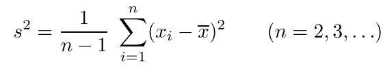

La deviazione standard è invece indicata con $s$ ed è definita come la radice quadrata della varianza campionaria:

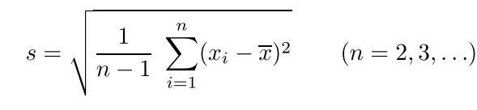

Varianza e deviazione standard sono detti indici di dispersione in quanto misurano la **dispersione dei dati intorno alla media**.  
La deviazione standard ha la stessa unità di misura dei valori osservati, mentre la varianza ha come unità di misura il quadrato dell’unità di misura dei valori di riferimento.

La deviazione standard viene detta anche **scarto quadratico medio** per come è definita.

Le proprietà della varianza sono le seguenti:

- **Non gode della proprietà di linearità**
- Sommare una costante a ciascuno dei dati non fa cambiare la varianza
- Moltiplicare i dati del campione per un fattore costante fa sì che la varianza campionaria risulti **moltiplicata per il quadrato di tale fattore**

Il valore della varianza è 0 quando tutti i valori sono uguali tra loro e **risulta essere più grande tanto più le osservazioni si discostano dalla media**.

In R per calcolare la varianza campionaria usiamo il comando var(), mentre per calcolare la deviazione standard usiamo la funzione sd().  
Valutiamo quindi quanto si disperdono i nostri dati rispetto alla media.  
Calcoliamo prima la varianza per ogni categoria:

```r
varianzaElementari <- var(licenza_elementare_o_nessuno)
varianzaElementari
```

```
## [1] 8.2525
```

```r
varianzaMedie <- var(licenza_media)
varianzaMedie
```

```
## [1] 18.04134
```

```r
varianzaDiploma <- var(diploma)
varianzaDiploma
```

```
## [1] 19.25734
```

```r
varianzaMaturita <- var(maturita)
varianzaMaturita
```

```
## [1] 11.42695
```

```r
varianzaLaurea <- var(laurea)
varianzaLaurea
```

```
## [1] 7.798842
```

Calcoliamo adesso la deviazione standard:

```r
deviazioneStandardElementari <- sd(licenza_elementare_o_nessuno)
deviazioneStandardElementari
```

```
## [1] 2.872716
```

```r
deviazioneStandardMedie <- sd(licenza_media)
deviazioneStandardMedie
```

```
## [1] 4.24751
```

```r
deviazioneStandardDiploma <- sd(diploma)
deviazioneStandardDiploma
```

```
## [1] 4.388319
```

```r
deviazioneStandardMaturita <- sd(maturita)
deviazioneStandardMaturita
```

```
## [1] 3.380377
```

```r
deviazioneStandardLaurea <- sd(laurea)
deviazioneStandardLaurea
```

```
## [1] 2.792641
```

Questi indici di dispersione sono relativi ai singoli dati presi in considerazione, se vogliamo però confrontare le variazioni tra diversi insiemi di dati si utilizza il **coefficiente di variazione**.

#### Coefficiente di variazione

Il coefficiente di variazione è un **numero puro**, è un indice adimensionale, cioè non dipende dall’unità di misura utilizzata (la media campionaria e la deviazione standard campionaria sono espressi in identiche unità di misura).  
È facile capire che il coefficiente di variazione ha senso che sia calcolato solo con campioni con **media campionaria non nulla**.  
**Non dobbiamo guardare alla varianza in senso assoluto, ma dobbiamo confrontarla con la media per fare una buona valutazione**.

Nel nostro caso è importante guardare al coefficiente di variazione perché ci interessa confrontare insiemi che hanno **differenti range di variazione**, cioè insiemi in cui la differenza tra il massimo e il minimo è molto diversa.

Il coefficiente risulta essere **sempre maggiore di 0**, ma **se compreso tra 0 e 1 vuol dire che la media è più grande della deviazione standard**.  
Invece più è grande più c’è dispersione nei dati e quindi il valore medio non è molto significativo.

Dato che in R non c’è una funzione per calcolare il coefficiente di variazione, introduciamo la seguente funzione:

```r
cv <- function (x){
        sd(x)/abs(mean(x))
      }
```

Utilizziamo quindi la funzione per ricavare l’indice per i nostri vettori:

```r
cvElementare <- cv(licenza_elementare_o_nessuno)
cvMedie <- cv(licenza_media)
cvDiploma <- cv(diploma)
cvMaturita <- cv(maturita)
cvLaurea <- cv(laurea)
```

Utilizziamo quindi la seguente tabella per avere un quadro totale degli indici ricavati per fare le nostre opportune analisi, in ordine di riga sono **riportate media, varianza, deviazione standard e coefficiente di variazione**:

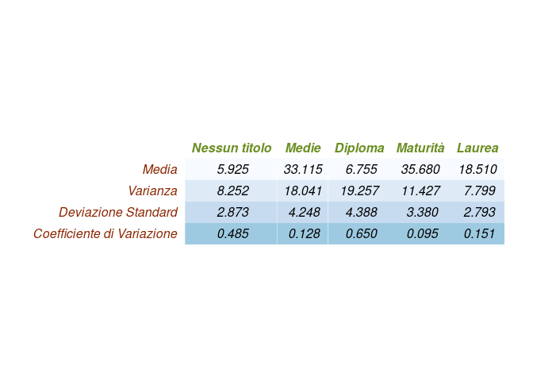

Dalla tabella notiamo come il coefficiente di variazione è minore per le variabili relative ai titoli medie, maturità e laurea, mentre è decisamente più alto per nessun titolo e soprattutto **diploma** dove si nota la variazione più grande tra i dati.

### Forma della distribuzione di frequenza

Gli indici trattati fino ad ora ci permettono già di intuire quale sia la forma della distribuzione di frequenza. Grazie ai dati sulla media e la mediana possiamo dire se c’è uno sbilanciamento verso destra o sinistra, vedendo se i valori differiscono e come differiscono, mentre con la moda possiamo dire se c’è un picco nella funzione, o più picchi.  
Introduciamo formalmente ora gli indici che permettono di misurare la **simmetria della funzione di distribuzione e la piccatezza**: **skewness e curtosi campionaria**.

#### Skewness

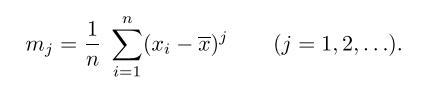

In base al valore della skewness abbiamo che:

- Se $\gamma1 = 0$, la distribuzione di frequenza è **simmetrica**
- Se $\gamma1 > 0$, la distribuzione di frequenza ha la **coda di destra più allungata per l’asimmetria positiva**
- Se $\gamma1 < 0$, la distribuzione di frequenza ha la **coda di sinistra più allungata per l’asimmetria negativa**

Definiamo una funzione per calcolare l’indice:

```r
skw <-function (x){
  n<-length (x)
  m2 <-(n -1)*var(x)/n
  m3 <- (sum( (x-mean(x))^3))/n
  m3/(m2 ^1.5)
}
```

E calcoliamo i valori:

```r
skw(licenza_elementare_o_nessuno)
```

```
## [1] 1.062309
```

```r
skw(licenza_media)
```

```
## [1] 0.8847151
```

```r
skw(diploma)
```

```
## [1] 1.268479
```

```r
skw(maturita)
```

```
## [1] 0.020537
```

```r
skw(laurea)
```

```
## [1] 0.08639237
```

#### Curtosi

Quello che facciamo tramite l’indice di curtosi è confrontare la distribuzione di frequenza dei nostri dati con una **densità di probabilità normale** caratterizzata da $\beta_2 = 3$ e indice di curtosi $\gamma_2 = 0$.

Risulta quindi:

- $\beta_2 < 3$, $\gamma_2 < 0$: la distribuzione di frequenza si definisce **platicurtica**, ossia la distribuzione di frequenza è **più piatta** di una normale
- $\beta_2 > 3$, $\gamma_2 > 0$: la distribuzione di frequenza si definisce **leptocurtica**, ossia la distribuzione di frequenza è **più piccata** di una normale
- $\beta_2 = 3$, $\gamma_2 = 0$: la distribuzione di frequenza si definisce **normocurtica**, ossia segue la curva di una normale

Definiamo quindi la funzione per calcolare l’indice nel seguente modo:

```r
curt <-function (x){
  n<-length (x)
  m2 <-(n-1)*var (x)/n
  m4 <- (sum( (x-mean(x))^4) )/n
  m4/(m2^2) -3
}
```

E calcoliamo i valori:

```r
curt(licenza_elementare_o_nessuno)
```

```
## [1] -0.4591248
```

```r
curt(licenza_media)
```

```
## [1] 0.09400184
```

```r
curt(diploma)
```

```
## [1] 1.492363
```

```r
curt(maturita)
```

```
## [1] -0.7978636
```

```r
curt(laurea)
```

```
## [1] -0.1815536
```

La curtosi risulta quindi negativa per la prima, la quarta e la quinta categoria, cioè **platicurtica**. Negli altri due casi è invece **leptocurtica**, anche se c’è da notare che il vettore licenza media si avvicina ad avere una forma normale.

## Statistica descrittiva Bivariata

Parliamo di statistica bivariata quando si va a confrontare e a studiare contemporaneamente **due caratteri** di una determinata popolazione.  
Quello che ci interessa fare è dunque **verificare e classificare le relazioni** esistenti tra caratteri quantitativi relativi alla stessa unità statistica.

Prima di tutto è opportuno definire uno scatterplot in cui ogni coppia di osservazioni è rappresentata nel piano euclideo, andando così a formare una nuvola di punti. Sull’ascisse viene posta quella che è definita **variabile indipendente**, mentre sulle ordine viene posta quella che viene definita **variabile dipendente**, e si disegnano dei punti in corrispondenza delle coppie $(x_i,y_i)$.  
Lo scopo di questo grafico è quello di far risaltare **eventuali pattern che legano le coppie di variabili**, sia a riguardo alla **forma** che alle **relazioni tra le categorie analizzate**.

Come già anticipato nel capitolo precedente, l’analisi verrà fatta prendendo in analisi le due categorie del nostro dataset relative alla percentuale di individui che hanno ottenuto al più la **licenza media e alla percentuale di chi ha conseguito una laurea** per ciascuna regione.

Di questi due vettori abbiamo già conoscenza degli indici di sintesi, che riportiamo di seguito:

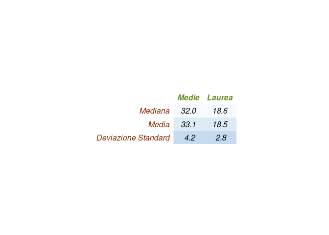

Mentre lo scatterplot relativo ai due vettori è il seguente, indicando anche mediana e media campionaria:

[figure not shown]

Dal grafico notiamo che i dati sembrano posizionati intorno ad una **retta discendente** e questo ci porta a pensare che tra i due caratteri ci sia una **correlazione lineare negativa**.

### Covarianza campionaria

Continuiamo l’indagine sulla dipendenza delle nostre variabili e lo facciamo introducendo una nuova **misura quantitativa** che descrive la correlazione, cioè la **covarianza campionaria** definita come di seguito:

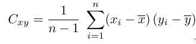

Da questa definizione notiamo che il prodotto interno alla sommatoria sarà **positivo per le osservazioni $(x_i,y_i)$ in cui le componenti della coppia sono o entrambe maggiori della media campionaria della variabile di cui fanno parte o entrambe minori**; il prodotto invece sarà **negativo** negli altri casi, cioè quando **una parte della coppia risulta essere maggiore e l’altra minore**.

Un’altra cosa da notare è che nella definizione la sommatoria viene divisa per $n-1$ e questo viene fatto per **normalizzarla** in quanto nel caso in cui le variabili x e y siano uguali **si ottiene la varianza campionaria**.

La covarianza può assumere i seguenti valori:

- Se $C_{xy} > 0$ le variabili sono **correlate positivamente**
- Se $C_{xy} < 0$ le variabili sono **correlate negativamente**
- Se $C_{xy} = 0$ le variabili considerate **non risultano essere correlate tra loro**, ciò vuol dire che i punti all’interno dello scatterplot sono tutti **sparsi**

Quando la covarianza campionaria assume valori positivi quindi quello che ci si aspetta è che i **cambiamenti della prima variabile siano corrispondenti anche nella seconda** (se una cresce anche l’altra lo fa, se una decresce anche l’altra lo fa); non c’è concordanza invece in una covarianza negativa.  
Una covarianza nulla invece indica che i dati non sono in relazione diretta tra loro.

Tra le proprietà della covarianza campionaria quindi abbiamo:

- $Cov(x,y) = Cov(y,x)$
- $Cov(x,x) = var(x)$

Calcoliamo la covarianza tra le nostre variabili con il comando cov() fornitoci da R:

```r
covarianzaMedLau <- cov(licenza_media,laurea)
covarianzaMedLau
```

```
## [1] -9.394895
```

La covarianza risulta, come avevamo previsto, **negativa** e questo indica che i due vettori sono correlati negativamente. Un problema della covarianza che ha come unità di misura: unità variabile x $\cdot$ unità variabile y.  
Solitamente si preferisce utilizzare qualcosa che faccia **perdere le unità di misura**, per questo motivo introduciamo il **coefficiente di correlazione campionaria**.

### Coefficiente di correlazione campionario

Il coefficiente di correlazione ha le seguenti caratteristiche:

- Prende valore tra **-1 e 1**
- È un **numero puro** senza dimensione
- Può essere calcolato solo se **entrambe le variabili sono quantitative**
- È fortemente influenzato da **valori anomali**

Il coefficiente di correlazione ha lo **stesso segno della covarianza**, e come precedentemente il segno ci dice se le variabili sono correlate positivamente, negativamente o non correlate.

Sul coefficiente di correlazione c’è da dire che:

1. se esistono due numeri reali $a$ e $b$, con $a > 0$, tali che $y_i = a x_i+b$ per ogni $i = 1, 2, .. , n$, allora $r_{xy} = 1$
2. se esistono due numeri reali $a$ e $b$, con $a < 0$, tali che $y_i = a x_i+b$ per ogni $i = 1, 2, .. , n$, allora $r_{xy} = -1$
3. se esistono quattro numeri reali $a$, $b$, $c$ e $d$, tali che $z_i = a x_i + b$ e $w_i =c y_i + d$ per $i = 1, 2, .. , n$, allora $r_{zw} = r_{xy}$ se $ac > 0$ e $r_{zw} = -r_{xy}$ se invece $ac < 0$.

Il punto 1 e il 2 dimostrano che i valori limite -1 e +1 sono effettivamente raggiunti solo quando tra **X e Y sussiste una relazione lineare**, ossia quando i punti dello scatterplot **giacciono tutti su di una retta**.  
Il punto 3 invece ci dice che il quadrato del coefficiente non cambia se sommiamo o moltiplichiamo costanti a tutti i valori di x e/o y.

In R possiamo calcolare il coefficiente di correlazione con la funzione Cor(), vediamolo:

```r
coefficienteCorrelazioneMedLau <- cor(licenza_media,laurea)
coefficienteCorrelazioneMedLau
```

```
## [1] -0.7920315
```

Vediamo come il coefficiente di correlazione è negativo e prossimo a **-0.8**, questo ci indica una decisa **correlazione lineare con una retta discendente** tra i vettori presi in considerazione.

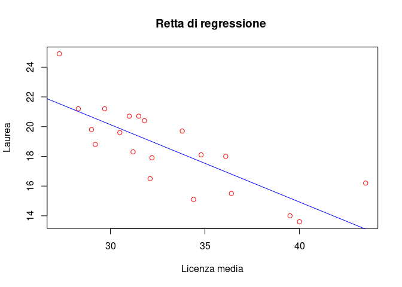

```r
plot(licenza_media ,laurea ,main="Retta di regressione ",
     xlab="Licenza media",ylab="Laurea", col ="red")
abline (lm(laurea~licenza_media ), col="blue")
```

Trattiamo più nel dettaglio dunque il concetto di regressione lineare.

### Regressione lineare

In statistica si parla di regressione lineare indicando un approccio che modella le relazioni tra una variabile detta dipendente e una o più variabili dette indipendenti.  
Il caso in cui la variabile indipendente sia una sola è detto **regressione lineare semplice**, mentre quando ci sono più variabili indipendenti abbiamo a che fare con la **regressione lineare multipla**.  
Nella regressione lineare le relazioni sono modellate usando funzioni di predizione lineare i cui parametri del modello sono stimati dai dati. Questi modelli sono detti **modelli lineari**.

### Regressione lineare semplice

Il **modello di regressione lineare semplice** è esprimibile attraverso l’**equazione di una retta che riesce meglio di qualunque altra ad interpolare la nuvola di punti**.
Data dunque l’equazione
$$Y = \alpha + \beta X$$
dove:

1. $\alpha$ è l’**intercetta**, cioè indica l’ordinata con la quale la retta di regressione si interseca con l’asse delle ordinate
2. $\beta$ è il **coefficiente angolare**, cioè indica la **“pendenza”** della retta.
- Se positivo allora la retta di regressione è crescente
- Se negativo allora la retta di regressione è discendente
- Se nullo allora la retta di regressione è orizzontale

Questa retta viene ottenuta con il **metodo dei minimi quadrati**.
Per calcolare i coefficienti di regressione è necessario considerare la **somma Q dei quadrati degli errori**
$$Q = \sum_{i=1}^n [y_i - (\alpha + \beta x_i)]^2$$
e minimizzarla. Quindi la variabile dipendente y viene “spiegata” attraverso una **relazione lineare della variabile indipendente x** (cioè: $\alpha + \beta x$).
Il problema della regressione si traduce nella determinazione di $\alpha$ e $\beta$ in modo da esprimere al meglio la relazione funzionale tra y e x.
Derivando Q rispetto $\alpha$ e $\beta$ e ponendo le derivate parziali ottenute a 0, il metodo dei minimi quadrati conduce a:
$$\beta = \frac{S_y}{S_x}r_{xy}, \qquad \qquad \alpha = \overline{y} - \beta \overline{x}$$

Notiamo come il coefficiente di correlazione influenza fortemente $\beta$ e se quest’ultimo è 0, allora la retta è **orizzontale**.

Possiamo quindi calcolare $\alpha$ e $\beta$ con le seguenti linee di codice:

```r
beta <-(sd(laurea )/sd(licenza_media ))*cor(licenza_media ,laurea)
alpha <-mean(laurea)-beta*mean(licenza_media)
c(alpha ,beta)
```

```
## [1] 35.7543900 -0.5207426
```

$\beta$ risulta negativa e infatti la nostra retta è **discendente**. Con $\alpha$ invece riusciamo a stimare dove la retta di regressione intercetta l’asse delle y.

Lo stesso risultato ci viene restituito dalla funzione **lm(y~x)** fornita da R in cui gli argomenti indicano che **y dipende da x**.  
Vediamo dunque:

```r
linearModel <- lm(laurea~licenza_media)
linearModel
```

```
##
## Call:
## lm(formula = laurea ~ licenza_media)
##
## Coefficients:
##   (Intercept)  licenza_media
##       35.7544        -0.5207
```

Linear model ci restituisce anche altre informazioni:

```r
attributes(linearModel)
```

```
## $names
##  [1] "coefficients"  "residuals"     "effects"       "rank"
##  [5] "fitted.values" "assign"        "qr"            "df.residual"
##  [9] "xlevels"       "call"          "terms"         "model"
##
## $class
## [1] "lm"
```

È presente ovviamente l’attributo coefficients che ci restituisce i coefficienti di regressione:

```r
linearModel$coefficients
```

```
##   (Intercept) licenza_media
##    35.7543900    -0.5207426
```

La retta di regressione ha quindi equazione:
$$y = 35.75439 - 0.52074x$$

#### Residui

Dopo aver trovato la retta di regressione, possiamo osservare qual è il **discostamento tra i valori osservati** (le coppie $(x_i,y_i)$) e i **valori stimati** (le coppie $(x_i,\hat{y_i})$).

I valori stimati sono espressi secondo l’equazione
$$\hat{y_i} = \alpha + \beta x_i$$
ottenuti mediante la retta di regressione. Risulta inoltre che la **media campionaria dei valori stimati è uguale alla media campionaria dei valori osservati**.

I residui sono dunque definiti come
$$E_i = y_i - \hat{y_i} = y_i - (\alpha + \beta x_i)$$
e mostrano di quanto si discostano valori osservati e valori stimati.

Si nota sui residui:

- La media campionaria dei residui risulta sempre **nulla**
- La varianza dei residui è $S_E^2 = \frac{1}{n-1}\sum_{i=1}^n E_i^2$ **in quanto la media campionaria è 0**

Per calcolare il **vettore dei valori stimati** utilizziamo la funzione fitted(),passando come argomento lm(y~x):

```r
valoriStimati <- fitted(lm(laurea~licenza_media))
valoriStimati
```

```
##        1        2        3        4        5        6        7        8
## 17.63255 16.95558 19.87174 19.19478 20.54871 18.98648 20.65286 20.28834
##        9       10       11       12       13       14       15       16
## 19.61137 21.01738 19.35100 21.53812 19.50722 18.15329 16.79936 15.18506
##       17       18       19       20
## 19.03855 17.84085 14.92469 13.10209
```

I valori stimati possono essere ottenuti anche attraverso l’attributo “fitted.values” di linear model:

```r
linearModel$fitted.values
```

```
##        1        2        3        4        5        6        7        8
## 17.63255 16.95558 19.87174 19.19478 20.54871 18.98648 20.65286 20.28834
##        9       10       11       12       13       14       15       16
## 19.61137 21.01738 19.35100 21.53812 19.50722 18.15329 16.79936 15.18506
##       17       18       19       20
## 19.03855 17.84085 14.92469 13.10209
```

Per calcolare i **residui** invece di usa la funzione resid() passando anche in questo caso lo stesso argomento:

```r
valoriResidui <- resid(lm(laurea~licenza_media))
valoriResidui
```

```
##          1          2          3          4          5          6
##  0.4674512  1.0444166 -0.2717418  1.2052235 -1.7487071 -1.0864794
##          7          8          9         10         11         12
## -0.8528556  0.9116641  1.0886295  0.1826246  1.3490008  3.3618820
##         13         14         15         16         17         18
## -1.2072220  1.5467087 -1.2993607 -1.1850587 -2.5385537 -2.7408458
##         19         20
## -1.3246875  3.0979115
```

I residui possono essere ottenuti anche attraverso l’attributo “residuals” di linear model:

```r
linearModel$residuals
```

```
##          1          2          3          4          5          6
##  0.4674512  1.0444166 -0.2717418  1.2052235 -1.7487071 -1.0864794
##          7          8          9         10         11         12
## -0.8528556  0.9116641  1.0886295  0.1826246  1.3490008  3.3618820
##         13         14         15         16         17         18
## -1.2072220  1.5467087 -1.2993607 -1.1850587 -2.5385537 -2.7408458
##         19         20
## -1.3246875  3.0979115
```

Dei residui possiamo calcolare **mediana, varianza e deviazione standard**, mentre non è possibile calcolare il coefficiente di variazione in quanto la media dei residui è 0.  
Vediamo dunque nel nostro caso:

```r
median(linearModel$residuals)
```

```
## [1] -0.04455862
```

```r
var(linearModel$residuals)
```

```
## [1] 2.906521
```

```r
sd(linearModel$residuals)
```

```
## [1] 1.704852
```

Rappresentiamo dunque graficamente i valori dei residui, vediamo tre possibili rappresentazioni:

1. aggiungiamo al grafico dello scatterpolot e la retta di regressione dei **segmenti verticali che visualizzano i residui**: congiungiamo i punti $(x_i,y_i)$) e i punti $(x_i,\hat{y_i})$

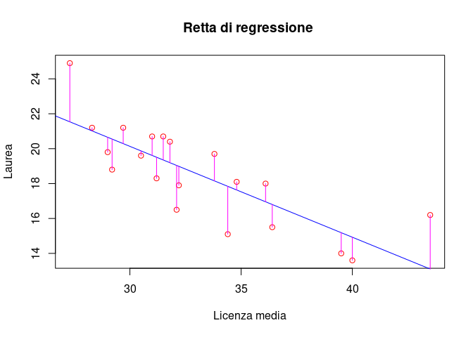

2. Usiamo un diagramma dei residui: un grafico in cui i valori dei residui sono posti sull’asse delle ordinate e quelli della variabile indipendente sull’asse delle ascisse

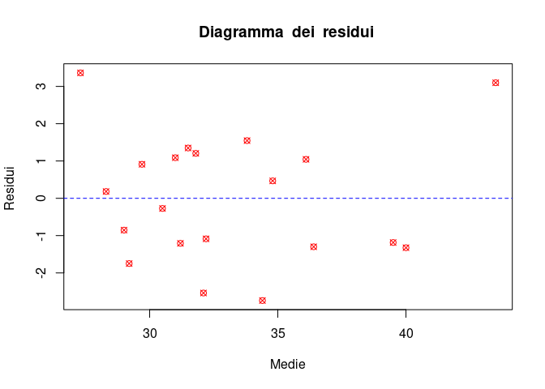

   Il diagramma dei residui aiuta a comprendere quale è l’**adattamento della retta di regressione rispetto ai dati**, consentendo di identificare quali sono le informazioni che hanno una forte **influenza sulla collocazione e direzione della retta di regressione**.  
   Occorre notare che la posizione della retta di regressione è fortemente influenzata dalla presenza di eventuali valori anomali che si discostano in modo significativo dagli altri. L’analisi dei residui aiuta ad individuare eventuali **punti isolati** (valori anomali) dovuti ad errori nella stima. Tali valori possono perturbare significativamente la stima dei parametri di regressione e influenzare l’interpretazione dei residui. Eliminando i valori anomali la varianza campionaria dei residui diminuisce.
3. Rappresentare i residui standardizzati rispetto ai valori stimati. I residui standardizzati sono definiti:
   $$E_i^{(s)} = \frac{E_i - \overline{E}}{s_E} = \frac{E_i}{s_E}$$
   caratterizzati da **media nulla e deviazione standard pari a 1**.

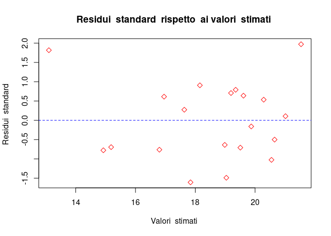

I punti indicano la **posizione dove si collocano i residui standardizzati rispetto ai valori stimati con la retta di regressione**. La retta orizzontale è posizionata nello zero, che corrisponde alla media campionaria dei residui standardizzati. Anche in questo caso i **punti sono disposti quasi casualmente attorno alla linea orizzontale e non si evidenzia nessuna tendenza particolare nella distribuzione dei punti**.

#### Coefficiente di determinazione

Un altro indice da considerare è il **coefficiente di determinazione**, definito come:

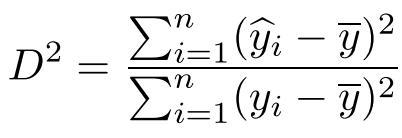

È definita cioè come il **rapporto tra varianza dei valori stimati** (con la retta di regressione) e **varianza dei valori osservati**.

Il coefficiente varia tra 0 e 1:

- Vicino ad **1 significa che i punti tenderanno ad allinearsi lungo la retta di regressione**
- Vicino a **0 non c’è una retta capace di interpolare i punti**

Nel caso della regressione lineare semplice il coefficiente di determinazione è il **quadrato del coefficiente di correlazione**, cioè
$$D^2 = r_{xy}^2$$

Per calcolarlo in R possiamo procedere nei due modi seguenti:

```r
(cor(licenza_media,laurea))^2
```

```
## [1] 0.6273138
```

```r
summary(linearModel)$r.square
```

```
## [1] 0.6273138
```

### Regressione lineare multipla

Non è insolito avere dei casi in cui è opportuno e interessante avere più di una variabile indipendente, e in questi casi parliamo di **regressione lineare multipla**.

Vediamo dunque qual è la relazione tra la variabile dipendente che abbiamo scelto “laurea” e le altre variabili del nostro dataset.  
Le funzioni **cov()** e **cor()** applicate alla matrice che rappresenta il nostro campione forniscono due matrici di dimensione 5x5 i cui elementi sono rispettivamente le **covarianze e i coefficienti di correlazione di ogni coppia di variabili**.  
**Sulla diagonale nel primo caso avremo la varianza, mentre nel secondo 1**.

```r
cov(matricePopolazionePerTitoloDiStudio)
```

```
##               Nessun titolo     Medie   Diploma  Maturità    Laurea
## Nessun titolo      8.252500  8.290658 -8.121447 -1.954211 -6.538158
## Medie              8.290658 18.041342 -9.096132 -7.935474 -9.394895
## Diploma           -8.121447 -9.096132 19.257342 -5.847263  3.868895
## Maturità          -1.954211 -7.935474 -5.847263 11.426947  4.341263
## Laurea            -6.538158 -9.394895  3.868895  4.341263  7.798842
```

```r
cor(matricePopolazionePerTitoloDiStudio)
```

```
##               Nessun titolo      Medie    Diploma   Maturità     Laurea
## Nessun titolo     1.0000000  0.6794567 -0.6442323 -0.2012396 -0.8149812
## Medie             0.6794567  1.0000000 -0.4880049 -0.5526795 -0.7920315
## Diploma          -0.6442323 -0.4880049  1.0000000 -0.3941753  0.3156993
## Maturità         -0.2012396 -0.5526795 -0.3941753  1.0000000  0.4598709
## Laurea           -0.8149812 -0.7920315  0.3156993  0.4598709  1.0000000
```

Notiamo che la correlazione più forte la otteniamo in corrispondenza di Laurea e Nessun titolo, e nel caso analizzato finora tra Laurea e Medie; mentre risultano poco correlate Nessun titolo e Maturità, ma anche Diploma e maturità. Notiamo inoltre che la maggior parte delle variabili sono **correlate tra loro negativamente**.

Riportiamo il grafico contenente tutti gli scatterplot per le coppie di variabili per dare una visione di insieme con i dati appena visti:

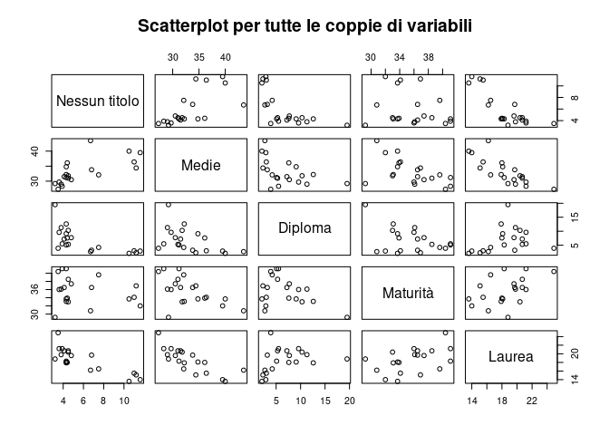

Il **modello di regressione lineare multipla** con p variabili è esprimibile con la seguente equazione:
$$Y = \alpha + \beta_1X_1 + \beta_2X_2 + ... + \beta_pX_p$$
dove:

1. $\alpha$ è l’intercetta
2. $\beta_1, \beta_2 ,... , \beta_p$ sono i **regressori**. $\beta_i$ rappresenta **l’inclinazione di Y rispetto alla variabile $X_i$ tenendo costanti le altre variabili**

Anche qui per stimare i parametri di regressione ricorriamo al **metodo dei minimi quadrati**, bisogna minimizzare la quantità:
$$Q = \sum_{i=1}^n [y_i - (\alpha + \beta_1x_{i,1} + \beta_2x_{i,2} + ... + \beta_px_{i,p})]^2$$

dove n è il numero delle osservazioni, $x_{1,j}, x_{2,j}, ... ,x_{n,j}$ sono i valori osservati dalla variabile $X_j$ e gli $y_i$ sono i valori osservati dalla variabile dipendente.
**Derivando** rispetto ai parametri $\alpha,\beta_1,\beta_2, ...,\beta_p$ si scopre che:
$$\alpha = \overline{y} - \beta_1\overline{x_1}- \beta_2\overline{x_2}- ... -\beta_p\overline{x_p}$$

In R per eseguire l’analisi di regressione lineare multipla usiamo sempre la funzione lm(y~x1 + x2 … +xp), cioè y è la variabile dipendente da x1,x2 …,xp.  
Vediamo dunque il codice:

```r
linearModelMultiplo <- lm(
                        laurea~licenza_media+
                        licenza_elementare_o_nessuno+
                        diploma+
                        maturita)
linearModelMultiplo
```

```
##
## Call:
## lm(formula = laurea ~ licenza_media + licenza_elementare_o_nessuno +
##     diploma + maturita)
##
## Coefficients:
##                  (Intercept)                 licenza_media
##                      100.590                        -1.008
## licenza_elementare_o_nessuno                       diploma
##                       -1.009                        -1.006
##                     maturita
##                       -1.007
```

Quindi l’intercetta $\alpha = 100.590$, mentre i regressori sono $\beta_1=-1.008, \beta_2=-1.009, \beta_3=-1.006, \beta_4=-1.007$ e il modello di regressione multipla risulta pertanto:
$$y = 100.590 -1.008x_1 -1.009x_2-1.006x_3-1.007x_4$$
Notiamo che **tutti i regressori sono negativi**, questo significa che le altre variabili sono tutte **legate negativamente alla percentuale delle persone che si laureano**.

Anche in questo caso lm() restituisce una serie di attributi tra cui anche i coefficienti di regressione.